# Cleaning/Analysis Script for Publication: Examining Comprehension of Meta-Analytic Effect Estimates

Shaina Trevino

2026-01-12

## Import

```r
#import data
cleaned_df <- import(here("data", "Cleaned full data 6.4.24.csv")) %>%
  janitor::clean_names() %>%
  filter(pid != "644bf248253fdfd230fa861f") # Remove test entry

#import demographic file
demo_df <- import(here("data", "Cleaned demographic data 6.4.csv")) %>%
  janitor::clean_names() %>%
  filter(participant_id != "644bf248253fdfd230fa861f") # Remove test entry

# Merge checks
merged_df <- left_join(cleaned_df, demo_df, by = c("pid" = "participant_id")) %>%  #left join to exclude participants dropped due to failing attention checks
  mutate(age = ifelse(age > 103, NA_real_, age)) #correct ages (105 and 104 was blank but exported as a wrong value)

not_in_cleaned <- demo_df %>%
    rename(pid = participant_id) %>%
    anti_join(cleaned_df, by = "pid") # 2 participants with demographic data but no study data

not_in_demo <- cleaned_df %>%
    rename(participant_id = pid) %>%
    anti_join(demo_df, by = "participant_id") # 3 participants with study data but no demographic data
```

## Tidy/Merge

`pid` in survey data is the `participant_id` in the demographic data (Prolific IDs)

```r
full_td <- demo_df %>%
  rename(pid = participant_id) %>%
  right_join(cleaned_df, by = "pid") %>% #right join to exclude participants dropped due to failing
  mutate(correct_comprehension_flag = case_when(more_or_less == "Less" ~ 1,
                                                more_or_less == "More" ~ 0,
                                                more_or_less == "Unsure" ~ 0,
                                                TRUE ~ NA_real_),
         correct_comprehension_flag = factor(correct_comprehension_flag,
                                             levels = c(0, 1),
                                             labels = c("Incorrect", "Correct")),
         precision_info_just_ci = factor(precision_info_just_ci,
                                             levels = c(0, 1),
                                             labels = c("No", "Yes")),
         precision_info_ci_included_at_all = factor(precision_info_ci_included_at_all,
                                             levels = c(0, 1),
                                             labels = c("No", "Yes")),
         effectiveness_cont = as.numeric(sub("([0-9]+).*", "\\1", effectiveness)),
         precision_cont = as.numeric(sub("([0-9]+).*", "\\1", precision)),
         group = factor(group,
                        levels = 1:6,
                        labels = c("SMD", "Cohen's U3", "CLES", "Risk ratio",
                                  "Number needed to treat", "IntHout probability of superiority")),
         sex = factor(sex),
         ethnicity_simplified = factor(ethnicity_simplified),
         age = ifelse(age > 103, NA_real_, age)) #correct ages (105 and 104 was blank but exported as a wrong value)
```

## Sample Summary Descriptives

OVERALL:

```r
# Overall age (mean, sd)
# demo_df %>%
#   summarise(
#     mean_age = mean(age, na.rm = TRUE),
#     sd_age   = sd(age, na.rm = TRUE),
#     min_age  = min(age, na.rm = TRUE),
#     max_age  = max(age, na.rm = TRUE),
#     n_missing_age = sum(is.na(age))
#   )

# Overall categorical variables with "Missing" as category
# Helper function to tabulate with missing
tab_with_missing <- function(df, var) {
  df %>%
    mutate({{ var }} := ifelse(is.na({{ var }}) | {{ var }} %in% c("DATA_EXPIRED", ""),
                               "Missing", as.character({{ var }}))) %>%
    count({{ var }}) %>%
    mutate(percent = 100 * n / sum(n))
}

sex_summary <- tab_with_missing(demo_df, sex)
ethnicity_summary <- tab_with_missing(demo_df, ethnicity_simplified)
country_summary <- tab_with_missing(demo_df, country_of_residence)
employment_summary <- tab_with_missing(demo_df, employment_status)
```

BY GROUP:

```r
# Age
# merged_df %>%
#   group_by(group) %>%
#   summarise(
#     mean_age = mean(age, na.rm = TRUE),
#     sd_age   = sd(age, na.rm = TRUE),
#     min_age  = min(age, na.rm = TRUE),
#     max_age  = max(age, na.rm = TRUE),
#     n_missing_age = sum(is.na(age)),
#     n = n()
#   )

# Helper function for categorical summary by group
# overall-denominator version
cat_by_group <- function(data, group, var) {
  total_N <- nrow(data)  # overall denominator

  data %>%
    mutate(var_clean = ifelse(is.na({{ var }}) | {{ var }} %in% c("DATA_EXPIRED",""),
                              "Missing", as.character({{ var }}))) %>%
    count({{ group }}, var_clean, name = "n") %>%
    mutate(percent = 100 * n / total_N)  # <-- overall denom
}

# By group x sex
#cat_by_group(merged_df, group, sex)

# By group x ethnicity
#cat_by_group(merged_df, group, ethnicity_simplified)

# By group x country of residence
#cat_by_group(merged_df, group, country_of_residence)

# By group x employment
#cat_by_group(merged_df, group, employment_status)
```

FULL TABLE

```r
# ---------------- Sample size row ----------------
make_sample_size_block <- function(data, group) {
  total_N <- nrow(data)
  group_sizes <- data %>% count({{ group }}, name = "n")

  # one-row tibble: Characteristic | Overall | <group1> | <group2> | ...
  bygrp_wide <- group_sizes %>%
    tidyr::pivot_wider(names_from = {{ group }}, values_from = n)

  tibble(Characteristic = "Sample size (n)", Overall = total_N) %>%
    cbind(bygrp_wide)
}

# --------------- Categorical blocks --------------
# Uses within-group denominators; Missing always shown last; levels sorted by overall n
make_cat_block <- function(data, group, var, label = NULL) {
  if (is.null(label)) label <- rlang::as_label(rlang::enquo(var))

  d <- data %>%
    mutate(level = ifelse(is.na({{ var }}) | {{ var }} %in% c("DATA_EXPIRED",""),
                          "Missing", as.character({{ var }})))

  total_N    <- nrow(d)
  group_sizes <- d %>% count({{ group }}, name = "N_group")

  # order levels by overall n, with Missing last
  overall_counts <- d %>% count(level, name = "n") %>%
    complete(level = union(level, "Missing"), fill = list(n = 0))
  level_order <- overall_counts %>%
    arrange(desc(n)) %>% pull(level) %>%
    (\(x) c(setdiff(x, "Missing"), "Missing"))()

  # Overall col (overall denominator)
  overall <- overall_counts %>%
    mutate(pct = 100 * n / total_N,
           Overall = sprintf("%d (%.1f%%)", n, pct)) %>%
    select(level, Overall) %>%
    arrange(match(level, level_order))

  # Group cols (within-group denominators)
  by_grp <- d %>%
    count({{ group }}, level, name = "n") %>%
    complete({{ group }}, level = level_order, fill = list(n = 0)) %>%
    left_join(group_sizes, by = rlang::as_name(rlang::ensym(group))) %>%
    mutate(pct = 100 * n / N_group,
           cell = sprintf("%d (%.1f%%)", n, pct)) %>%
    select({{ group }}, level, cell) %>%
    pivot_wider(names_from = {{ group }}, values_from = cell) %>%
    arrange(match(level, level_order))

  bind_rows(
    tibble(Characteristic = label, Overall = NA_character_),
    left_join(overall, by_grp, by = "level") %>%
      transmute(Characteristic = paste0("  ", level),
                Overall, across(-level, identity))
  )
}

# ---------------- Age block (adds Missing) ----------------
# Missing shown, with within-group denominators for group columns
make_age_block_with_missing <- function(data, group) {
  total_N <- nrow(data)
  group_sizes <- data %>% count({{ group }}, name = "N_group")

  # overall descriptive stats
  over <- data %>%
    summarise(
      mean = mean(age, na.rm = TRUE),
      sd   = sd(age, na.rm = TRUE),
      min  = suppressWarnings(min(age, na.rm = TRUE)),
      max  = suppressWarnings(max(age, na.rm = TRUE))
    )

  age_rows <- tibble(
    Characteristic = c("Age, mean (SD)", "Age, range"),
    Overall = c(sprintf("%.1f (%.1f)", over$mean, over$sd),
                sprintf("%d–%d", over$min, over$max))
  )

  bygrp_stats <- data %>%
    group_by({{ group }}) %>%
    summarise(
      mean = mean(age, na.rm = TRUE),
      sd   = sd(age,   na.rm = TRUE),
      min  = suppressWarnings(min(age, na.rm = TRUE)),
      max  = suppressWarnings(max(age, na.rm = TRUE)),
      .groups = "drop"
    ) %>%
    transmute(
      {{ group }},
      `Age, mean (SD)` = sprintf("%.1f (%.1f)", mean, sd),
      `Age, range`     = sprintf("%d–%d", min, max)
    ) %>%
    pivot_longer(-{{ group }}, names_to = "Characteristic", values_to = "val") %>%
    pivot_wider(names_from = {{ group }}, values_from = val)

  # Missing: overall (overall denom) + by group (within-group denom), show 0 (0.0%)
  overall_miss <- sum(is.na(data$age))
  overall_miss_cell <- sprintf("%d (%.1f%%)", overall_miss, 100 * overall_miss / total_N)

  bygrp_miss <- data %>%
    mutate(miss = is.na(age)) %>%
    count({{ group }}, miss, name = "n") %>%
    complete({{ group }}, miss = TRUE, fill = list(n = 0)) %>%  # ensures row exists for every group
    filter(miss) %>%
    left_join(group_sizes, by = rlang::as_name(rlang::ensym(group))) %>%
    mutate(cell = sprintf("%d (%.1f%%)", n, 100 * n / N_group)) %>%
    select({{ group }}, cell) %>%
    pivot_wider(names_from = {{ group }}, values_from = cell)

  bind_rows(
    age_rows %>% left_join(bygrp_stats, by = "Characteristic"),
    cbind(tibble(Characteristic = "  Missing", Overall = overall_miss_cell), bygrp_miss)
  )
}

# ---------------- Numeracy block (adds Missing) ----------------
# Missing shown, with within-group denominators for group columns
make_numeracy_block_with_missing <- function(data, group) {
  total_N <- nrow(data)
  group_sizes <- data %>% count({{ group }}, name = "N_group")

  # overall descriptive stats
  over <- data %>%
    summarise(
      mean = mean(num_score, na.rm = TRUE),
      sd   = sd(num_score,   na.rm = TRUE),
      min  = suppressWarnings(min(num_score, na.rm = TRUE)),
      max  = suppressWarnings(max(num_score, na.rm = TRUE))
    )

  num_rows <- tibble(
    Characteristic = c("Numeracy score, mean (SD)", "Numeracy score, range"),
    Overall        = c(sprintf("%.1f (%.1f)", over$mean, over$sd),
                       sprintf("%g–%g", over$min, over$max))
  )

  bygrp_stats <- data %>%
    group_by({{ group }}) %>%
    summarise(
      mean = mean(num_score, na.rm = TRUE),
      sd   = sd(num_score,   na.rm = TRUE),
      min  = suppressWarnings(min(num_score, na.rm = TRUE)),
      max  = suppressWarnings(max(num_score, na.rm = TRUE)),
      .groups = "drop"
    ) %>%
    transmute(
      {{ group }},
      `Numeracy score, mean (SD)` = sprintf("%.1f (%.1f)", mean, sd),
      `Numeracy score, range`     = sprintf("%g–%g", min, max)
    ) %>%
    pivot_longer(-{{ group }}, names_to = "Characteristic", values_to = "val") %>%
    pivot_wider(names_from = {{ group }}, values_from = val)

  # Missing: overall + by group
  overall_miss <- sum(is.na(data$num_score))
  overall_miss_cell <- sprintf(
    "%d (%.1f%%)", overall_miss, 100 * overall_miss / total_N
  )

  bygrp_miss <- data %>%
    mutate(miss = is.na(num_score)) %>%
    count({{ group }}, miss, name = "n") %>%
    complete({{ group }}, miss = TRUE, fill = list(n = 0)) %>%
    filter(miss) %>%
    left_join(group_sizes, by = rlang::as_name(rlang::ensym(group))) %>%
    mutate(cell = sprintf("%d (%.1f%%)", n, 100 * n / N_group)) %>%
    select({{ group }}, cell) %>%
    pivot_wider(names_from = {{ group }}, values_from = cell)

  bind_rows(
    num_rows %>% left_join(bygrp_stats, by = "Characteristic"),
    cbind(
      tibble(Characteristic = "  Missing", Overall = overall_miss_cell),
      bygrp_miss
    )
  )
}

# ---------------- Build your Table 1 ----------------
sample_block <- make_sample_size_block(merged_df, group)
age_block    <- make_age_block_with_missing(merged_df, group)
num_block    <- make_numeracy_block_with_missing(merged_df, group)
sex_block    <- make_cat_block(merged_df, group, sex, "Sex")
eth_block    <- make_cat_block(merged_df, group, ethnicity_simplified, "Race/ethnicity")
ctr_block    <- make_cat_block(merged_df, group, country_of_residence, "Country of residence")
emp_block    <- make_cat_block(merged_df, group, employment_status, "Employment status")

# Coerce all non-Characteristic columns to character so types align
to_char <- function(df) dplyr::mutate(df, dplyr::across(-Characteristic, as.character))
table1_df <- dplyr::bind_rows(
  to_char(sample_block),
  to_char(age_block),
  to_char(num_block),
  to_char(sex_block),
  to_char(eth_block),
  to_char(ctr_block),
  to_char(emp_block)
)

table1_df[is.na(table1_df)] <- ""

table1_gt <- gt(table1_df) |>
  tab_header(title = "Participant Demographics (Overall and by Group)") |>
  cols_label(Characteristic = "Characteristic", Overall = "Overall",
             `1` = "SMD", `2` = "CU3", `3` = "CLES", `4` = "RR", `5` = "NNT", `6` = "IntHout") |>
  tab_options(table.font.size = "small")

table1_gt
```

Participant Demographics (Overall and by Group)

| Characteristic | Overall | SMD | CU3 | CLES | RR | NNT | IntHout |
| --- | --- | --- | --- | --- | --- | --- | --- |
| Sample size (n) | 1189 | 195 | 198 | 198 | 202 | 191 | 205 |
| Age, mean (SD) | 46.9 (17.4) | 47.2 (17.2) | 46.7 (18.4) | 46.5 (18.0) | 48.1 (17.3) | 45.5 (17.0) | 47.5 (16.4) |
| Age, range | 18–94 | 18–86 | 19–92 | 20–87 | 18–89 | 19–94 | 18–82 |
| Missing | 5 (0.4%) | 0 (0.0%) | 1 (0.5%) | 0 (0.0%) | 0 (0.0%) | 2 (1.0%) | 2 (1.0%) |
| Numeracy score, mean (SD) | 4.7 (1.5) | 4.7 (1.5) | 4.7 (1.4) | 4.8 (1.5) | 4.8 (1.5) | 4.7 (1.4) | 4.8 (1.6) |
| Numeracy score, range | 1–9 | 1–9 | 1–9 | 1–9 | 1–9 | 1–9 | 1–9 |
| Missing | 0 (0.0%) | 0 (0.0%) | 0 (0.0%) | 0 (0.0%) | 0 (0.0%) | 0 (0.0%) | 0 (0.0%) |
| Sex |  |  |  |  |  |  |  |
| Female | 603 (50.7%) | 96 (49.2%) | 102 (51.5%) | 93 (47.0%) | 114 (56.4%) | 94 (49.2%) | 104 (50.7%) |
| Male | 583 (49.0%) | 99 (50.8%) | 95 (48.0%) | 105 (53.0%) | 88 (43.6%) | 96 (50.3%) | 100 (48.8%) |
| Missing | 3 (0.3%) | 0 (0.0%) | 1 (0.5%) | 0 (0.0%) | 0 (0.0%) | 1 (0.5%) | 1 (0.5%) |
| Race/ethnicity |  |  |  |  |  |  |  |
| White | 762 (64.1%) | 124 (63.6%) | 132 (66.7%) | 128 (64.6%) | 140 (69.3%) | 101 (52.9%) | 137 (66.8%) |
| Black | 141 (11.9%) | 18 (9.2%) | 23 (11.6%) | 27 (13.6%) | 16 (7.9%) | 35 (18.3%) | 22 (10.7%) |
| Mixed | 127 (10.7%) | 29 (14.9%) | 17 (8.6%) | 19 (9.6%) | 21 (10.4%) | 23 (12.0%) | 18 (8.8%) |
| Other | 90 (7.6%) | 16 (8.2%) | 13 (6.6%) | 14 (7.1%) | 11 (5.4%) | 18 (9.4%) | 18 (8.8%) |
| Asian | 66 (5.6%) | 8 (4.1%) | 12 (6.1%) | 10 (5.1%) | 14 (6.9%) | 13 (6.8%) | 9 (4.4%) |
| Missing | 3 (0.3%) | 0 (0.0%) | 1 (0.5%) | 0 (0.0%) | 0 (0.0%) | 1 (0.5%) | 1 (0.5%) |
| Country of residence |  |  |  |  |  |  |  |
| United States | 1186 (99.7%) | 195 (100.0%) | 197 (99.5%) | 198 (100.0%) | 202 (100.0%) | 190 (99.5%) | 204 (99.5%) |
| Missing | 3 (0.3%) | 0 (0.0%) | 1 (0.5%) | 0 (0.0%) | 0 (0.0%) | 1 (0.5%) | 1 (0.5%) |
| Employment status |  |  |  |  |  |  |  |
| Full-Time | 378 (31.8%) | 52 (26.7%) | 58 (29.3%) | 70 (35.4%) | 72 (35.6%) | 60 (31.4%) | 66 (32.2%) |
| Not in paid work (e.g. homemaker', 'retired or disabled) | 198 (16.7%) | 34 (17.4%) | 39 (19.7%) | 31 (15.7%) | 35 (17.3%) | 22 (11.5%) | 37 (18.0%) |
| Part-Time | 149 (12.5%) | 24 (12.3%) | 27 (13.6%) | 25 (12.6%) | 29 (14.4%) | 24 (12.6%) | 20 (9.8%) |
| Unemployed (and job seeking) | 85 (7.1%) | 14 (7.2%) | 15 (7.6%) | 10 (5.1%) | 14 (6.9%) | 12 (6.3%) | 20 (9.8%) |
| Other | 41 (3.4%) | 12 (6.2%) | 5 (2.5%) | 7 (3.5%) | 8 (4.0%) | 4 (2.1%) | 5 (2.4%) |
| Due to start a new job within the next month | 7 (0.6%) | 1 (0.5%) | 1 (0.5%) | 1 (0.5%) | 0 (0.0%) | 3 (1.6%) | 1 (0.5%) |
| Missing | 331 (27.8%) | 58 (29.7%) | 53 (26.8%) | 54 (27.3%) | 44 (21.8%) | 66 (34.6%) | 56 (27.3%) |

```r
#gtsave(table1_gt, here::here("outputs/participant_demographics.png"))
```

## Results

### Descriptively: Do groups differ in their ES comprehension

1. Are education practitioners able to accurately interpret each effect size?
- Describe the proportion of participants that were able to answer `more_or_less` interpretation question correctly in each group?

```r
#select analysis variables
rq1_df <- full_td %>%
  select(pid, group, more_or_less, correct_comprehension_flag, num_score, age, sex, ethnicity_simplified)
```

```r
correct_prop <- rq1_df %>%
  group_by(group) %>%
  mutate(group_total = n()) %>%
  group_by(group, correct_comprehension_flag) %>%
  summarize(n = n(),
            percent = paste0(round(n / first(group_total) * 100, 2), "%")) %>%
  mutate(n_percent = paste0(n, " (", percent, ")")) %>%
  arrange(n) %>%
  select(-n, -percent) %>%
  pivot_wider(names_from = correct_comprehension_flag,
    values_from = n_percent) %>%
  select(group, Correct, Incorrect)

correct_prop
```

```
## # A tibble: 6 × 3
## # Groups:   group [6]
##   group                              Correct      Incorrect
##   <fct>                              <chr>        <chr>
## 1 SMD                                188 (96.41%) 7 (3.59%)
## 2 Cohen's U3                         187 (94.44%) 11 (5.56%)
## 3 Risk ratio                         184 (91.09%) 18 (8.91%)
## 4 IntHout probability of superiority 182 (88.78%) 23 (11.22%)
## 5 CLES                               153 (77.27%) 45 (22.73%)
## 6 Number needed to treat             80 (41.88%)  111 (58.12%)
```

### RQ1: How does participant comprehension of the effect vary by effect size presented? (From F&T: “are participants able to accurately interpret each ES” which type of ES lead to most accurate understanding”)

Outcome: effect size comprehension (`more_or_less`) - Q: Did students in the depression prevention programs report more or less depression symptoms after participating? - Options: More, Less, Unsure - Correct response: Less

ES Groups (based on the effect size the participant sees; `group`): - 1 = SMD - 2 = Cohen’s U3 - 3 = CLES - 4 = Risk ratio - 5 = Number needed to treat - 6 = IntHout probability of superiority (PSES)

Analysis plan: multinomial regression with categorical outcome Covariates: - Numeracy level (1-9): `num_score` - Age (continuous variable): `age` - Sex (male/female): `sex` - Race/ethnicity (White, Mixed, Asian, Black and Other): `ethnicity_simplified`

```r
# create factors
rq1_df2 <- rq1_df %>%
  mutate(
    comprehension_cat = case_when(
      more_or_less == "Less" ~ "Correct",
      more_or_less == "More" ~ "Incorrect",
      more_or_less == "Unsure" ~ "Unsure",
      TRUE ~ NA_character_
    ),
    comprehension_cat = factor(
      comprehension_cat,
      levels = c("Correct", "Incorrect", "Unsure")
    )
  ) %>%
  filter(complete.cases(comprehension_cat, group, num_score, age, sex, ethnicity_simplified)) # 5 cases dropped



# descriptives
desc_tab <- rq1_df2 %>%
  count(group, comprehension_cat) %>%
  group_by(group) %>%
  mutate(pct = 100*n/sum(n)) %>%
  ungroup()

desc_tab
```

```
## # A tibble: 18 × 4
##    group                              comprehension_cat     n   pct
##    <fct>                              <fct>             <int> <dbl>
##  1 SMD                                Correct             188 96.4
##  2 SMD                                Incorrect             2  1.03
##  3 SMD                                Unsure                5  2.56
##  4 Cohen's U3                         Correct             186 94.4
##  5 Cohen's U3                         Incorrect             4  2.03
##  6 Cohen's U3                         Unsure                7  3.55
##  7 CLES                               Correct             153 77.3
##  8 CLES                               Incorrect            13  6.57
##  9 CLES                               Unsure               32 16.2
## 10 Risk ratio                         Correct             184 91.1
## 11 Risk ratio                         Incorrect             4  1.98
## 12 Risk ratio                         Unsure               14  6.93
## 13 Number needed to treat             Correct              79 41.8
## 14 Number needed to treat             Incorrect            16  8.47
## 15 Number needed to treat             Unsure               94 49.7
## 16 IntHout probability of superiority Correct             180 88.7
## 17 IntHout probability of superiority Incorrect            11  5.42
## 18 IntHout probability of superiority Unsure               12  5.91
```

```r
## make into table
# 1) Count + percent, keep all combos (including 0s)
desc_wide <- rq1_df2 %>%
  mutate(
    # choose your display order here:
    comprehension_cat = factor(
      comprehension_cat,
      levels = c("Unsure", "Incorrect", "Correct")
    )
  ) %>%
  count(group, comprehension_cat, .drop = FALSE) %>%
  group_by(group) %>%
  mutate(
    pct   = 100 * n / sum(n),
    cell  = sprintf("%d (%.1f%%)", n, pct),
    total = sum(n)
  ) %>%
  ungroup() %>%
  select(group, total, comprehension_cat, cell) %>%
  pivot_wider(
    names_from  = comprehension_cat,
    values_from = cell,
    values_fill = "0 (0.0%)"
  ) %>%
  arrange(group)

# 2) Make the gt table
gt_desc_tbl <- gt(desc_wide) %>%
  cols_label(
    group    = "Group",
    total    = "Total N",
    Unsure   = "Unsure",
    Incorrect= "Incorrect",
    Correct  = "Correct"
  ) %>%
  cols_align(align = "center", columns = -group) %>%
  tab_header(
    title = "Comprehension by Group",
    #subtitle = "Cells show count (row %) within each group"
  ) %>%
  tab_options(table.font.size = px(13))

gt_desc_tbl
```

Comprehension by Group

| Group | Total N | Unsure | Incorrect | Correct |
| --- | --- | --- | --- | --- |
| SMD | 195 | 5 (2.6%) | 2 (1.0%) | 188 (96.4%) |
| Cohen's U3 | 197 | 7 (3.6%) | 4 (2.0%) | 186 (94.4%) |
| CLES | 198 | 32 (16.2%) | 13 (6.6%) | 153 (77.3%) |
| Risk ratio | 202 | 14 (6.9%) | 4 (2.0%) | 184 (91.1%) |
| Number needed to treat | 189 | 94 (49.7%) | 16 (8.5%) | 79 (41.8%) |
| IntHout probability of superiority | 203 | 12 (5.9%) | 11 (5.4%) | 180 (88.7%) |

```r
# Updated analysis on 11/6/25 to run multinomial logistic regression with emmeans to include covariates and get tukey comparisons
mn_df <- rq1_df2 %>%
  rename(es_group = group)

fit_mn <- multinom(
  comprehension_cat ~ es_group + num_score + age + sex + ethnicity_simplified,
  data = mn_df, trace = FALSE, Hess = TRUE
)
summary(fit_mn)
```

```
## Call:
## multinom(formula = comprehension_cat ~ es_group + num_score +
##     age + sex + ethnicity_simplified, data = mn_df, Hess = TRUE,
##     trace = FALSE)
##
## Coefficients:
##           (Intercept) es_groupCohen's U3 es_groupCLES es_groupRisk ratio
## Incorrect   -2.399767          0.8369719     2.192113          0.7905692
## Unsure      -3.975784          0.3167260     2.078625          0.9929312
##           es_groupNumber needed to treat
## Incorrect                       2.918405
## Unsure                          3.905032
##           es_groupIntHout probability of superiority   num_score         age
## Incorrect                                  1.8256803 -0.48059388 0.003675534
## Unsure                                     0.8897061  0.01618462 0.002926643
##              sexMale ethnicity_simplifiedBlack ethnicity_simplifiedMixed
## Incorrect  0.1484024                 0.1492288                0.04981418
## Unsure    -0.5907456                 0.2033058               -0.16587432
##           ethnicity_simplifiedOther ethnicity_simplifiedWhite
## Incorrect                -0.7748996                -0.6979065
## Unsure                    0.3047374                 0.5330813
##
## Std. Errors:
##           (Intercept) es_groupCohen's U3 es_groupCLES es_groupRisk ratio
## Incorrect   1.1621305          0.8800511    0.7769507          0.8813191
## Unsure      0.7806599          0.5960727    0.4952259          0.5330060
##           es_groupNumber needed to treat
## Incorrect                      0.7723091
## Unsure                         0.4830397
##           es_groupIntHout probability of superiority num_score         age
## Incorrect                                  0.7844765 0.1059219 0.009207659
## Unsure                                     0.5438348 0.0703739 0.005727542
##             sexMale ethnicity_simplifiedBlack ethnicity_simplifiedMixed
## Incorrect 0.3069367                 0.7034716                 0.7349287
## Unsure    0.2038968                 0.5189199                 0.5523748
##           ethnicity_simplifiedOther ethnicity_simplifiedWhite
## Incorrect                 0.8718975                 0.6647386
## Unsure                    0.5613104                 0.4566401
##
## Residual Deviance: 1048.569
## AIC: 1100.569
```

```r
confint(fit_mn)
```

```
## , , Incorrect
##
##                                                  2.5 %      97.5 %
## (Intercept)                                -4.67750105 -0.12203305
## es_groupCohen's U3                         -0.88789653  2.56184034
## es_groupCLES                                0.66931788  3.71490851
## es_groupRisk ratio                         -0.93678444  2.51792290
## es_groupNumber needed to treat              1.40470695  4.43210316
## es_groupIntHout probability of superiority  0.28813464  3.36322589
## num_score                                  -0.68819695 -0.27299081
## age                                        -0.01437115  0.02172221
## sexMale                                    -0.45318254  0.74998731
## ethnicity_simplifiedBlack                  -1.22955019  1.52800783
## ethnicity_simplifiedMixed                  -1.39061963  1.49024800
## ethnicity_simplifiedOther                  -2.48378719  0.93398803
## ethnicity_simplifiedWhite                  -2.00077029  0.60495730
##
## , , Unsure
##
##                                                   2.5 %      97.5 %
## (Intercept)                                -5.505849230 -2.44571865
## es_groupCohen's U3                         -0.851554932  1.48500696
## es_groupCLES                                1.108000034  3.04924970
## es_groupRisk ratio                         -0.051741251  2.03760375
## es_groupNumber needed to treat              2.958291108  4.85177200
## es_groupIntHout probability of superiority -0.176190610  1.95560277
## num_score                                  -0.121745689  0.15411493
## age                                        -0.008299133  0.01415242
## sexMale                                    -0.990375927 -0.19111531
## ethnicity_simplifiedBlack                  -0.813758472  1.22037010
## ethnicity_simplifiedMixed                  -1.248509073  0.91676043
## ethnicity_simplifiedOther                  -0.795410853  1.40488563
## ethnicity_simplifiedWhite                  -0.361916858  1.42807940
```

```r
# ORs
exp(coef(fit_mn))
```

```
##           (Intercept) es_groupCohen's U3 es_groupCLES es_groupRisk ratio
## Incorrect  0.09073909           2.309363     8.954115           2.204651
## Unsure     0.01876459           1.372626     7.993469           2.699135
##           es_groupNumber needed to treat
## Incorrect                       18.51174
## Unsure                          49.65165
##           es_groupIntHout probability of superiority num_score      age
## Incorrect                                   6.207016  0.618416 1.003682
## Unsure                                      2.434414  1.016316 1.002931
##             sexMale ethnicity_simplifiedBlack ethnicity_simplifiedMixed
## Incorrect 1.1599796                  1.160939                 1.0510758
## Unsure    0.5539141                  1.225447                 0.8471527
##           ethnicity_simplifiedOther ethnicity_simplifiedWhite
## Incorrect                  0.460750                  0.497626
## Unsure                     1.356269                  1.704175
```

```r
# OR CIs
exp(confint(fit_mn))
```

```
## , , Incorrect
##
##                                                  2.5 %     97.5 %
## (Intercept)                                0.009302231  0.8851191
## es_groupCohen's U3                         0.411520462 12.9596455
## es_groupCLES                               1.952904747 41.0548307
## es_groupRisk ratio                         0.391885945 12.4028081
## es_groupNumber needed to treat             4.074332573 84.1081242
## es_groupIntHout probability of superiority 1.333936898 28.8822117
## num_score                                  0.502481253  0.7610998
## age                                        0.985731626  1.0219599
## sexMale                                    0.635602101  2.1169732
## ethnicity_simplifiedBlack                  0.292424083  4.6089858
## ethnicity_simplifiedMixed                  0.248921018  4.4381960
## ethnicity_simplifiedOther                  0.083426674  2.5446370
## ethnicity_simplifiedWhite                  0.135231075  1.8311740
##
## , , Unsure
##
##                                                   2.5 %       97.5 %
## (Intercept)                                 0.004062937   0.08666383
## es_groupCohen's U3                          0.426750847   4.41499613
## es_groupCLES                                3.028295847  21.09950742
## es_groupRisk ratio                          0.949574536   7.67220261
## es_groupNumber needed to treat             19.265021775 127.96694682
## es_groupIntHout probability of superiority  0.838458150   7.06817822
## num_score                                   0.885373500   1.16662495
## age                                         0.991735209   1.01425304
## sexMale                                     0.371437032   0.82603733
## ethnicity_simplifiedBlack                   0.443189218   3.38844157
## ethnicity_simplifiedMixed                   0.286932273   2.50117453
## ethnicity_simplifiedOther                   0.451395739   4.07506065
## ethnicity_simplifiedWhite                   0.696340261   4.17068128
```

```r
# Omnibus likelihood-ratio test (chi-square overall)
ancova_mn <- car::Anova(fit_mn, type = 3)
ancova_mn
```

```
## Analysis of Deviance Table (Type III tests)
##
## Response: comprehension_cat
##                      LR Chisq Df Pr(>Chisq)
## es_group              259.165 10  < 2.2e-16 ***
## num_score              22.964  2  1.032e-05 ***
## age                     0.371  2   0.830821
## sex                     9.417  2   0.009018 **
## ethnicity_simplified   13.734  8   0.088974 .
## ---
## Signif. codes:  0 '***' 0.001 '**' 0.01 '*' 0.05 '.' 0.1 ' ' 1
```

```r
# N included in model
sum(complete.cases(mn_df[, c(
  "comprehension_cat",
  "es_group",
  "num_score",
  "age",
  "sex",
  "ethnicity_simplified"
)]))
```

```
## [1] 1184
```

```r
# (3) Estimated marginal means for each group × outcome
emm_rq1_mn <- emmeans(fit_mn, ~ es_group | comprehension_cat, type = "response")

# (4) All pairwise Tukey contrasts *for each outcome category*
pairs_all <- contrast(emm_rq1_mn, "pairwise", by = "comprehension_cat", adjust = "tukey") %>%
  summary(infer = TRUE, type = "response")

pairs_all
```

```
## comprehension_cat = Correct:
##  contrast                                                    estimate     SE df
##  SMD - Cohen's U3                                             0.01953 0.0192 26
##  SMD - CLES                                                   0.17768 0.0334 26
##  SMD - Risk ratio                                             0.04420 0.0213 26
##  SMD - Number needed to treat                                 0.51941 0.0418 26
##  SMD - IntHout probability of superiority                     0.07233 0.0253 26
##  Cohen's U3 - CLES                                            0.15815 0.0341 26
##  Cohen's U3 - Risk ratio                                      0.02467 0.0231 26
##  Cohen's U3 - Number needed to treat                          0.49988 0.0423 26
##  Cohen's U3 - IntHout probability of superiority              0.05279 0.0265 26
##  CLES - Risk ratio                                           -0.13348 0.0346 26
##  CLES - Number needed to treat                                0.34173 0.0467 26
##  CLES - IntHout probability of superiority                   -0.10535 0.0361 26
##  Risk ratio - Number needed to treat                          0.47521 0.0425 26
##  Risk ratio - IntHout probability of superiority              0.02813 0.0278 26
##  Number needed to treat - IntHout probability of superiority -0.44708 0.0441 26
##  lower.CL  upper.CL t.ratio p.value
##  -0.03941  0.078472   1.018  0.9076
##   0.07501  0.280344   5.317  0.0002
##  -0.02114  0.109542   2.078  0.3288
##   0.39111  0.647710  12.438  <.0001
##  -0.00541  0.150060   2.859  0.0791
##   0.05348  0.262809   4.642  0.0011
##  -0.04643  0.095764   1.066  0.8903
##   0.36989  0.629860  11.816  <.0001
##  -0.02851  0.134098   1.995  0.3719
##  -0.23991 -0.027050  -3.853  0.0080
##   0.19811  0.485355   7.310  <.0001
##  -0.21617  0.005464  -2.921  0.0694
##   0.34452  0.605893  11.172  <.0001
##  -0.05737  0.113626   1.011  0.9101
##  -0.58263 -0.311537 -10.134  <.0001
##
## comprehension_cat = Incorrect:
##  contrast                                                    estimate     SE df
##  SMD - Cohen's U3                                            -0.01215 0.0130 26
##  SMD - CLES                                                  -0.06095 0.0225 26
##  SMD - Risk ratio                                            -0.01067 0.0124 26
##  SMD - Number needed to treat                                -0.07537 0.0243 26
```

[output cut: 51 more lines]

```
##  -0.19235 -0.026333  -4.047  0.0050
##  -0.08186  0.029565  -1.442  0.7021
##  -0.56383 -0.309469 -10.549  <.0001
##  -0.07304  0.034159  -1.114  0.8710
##  -0.00259  0.168980   2.980  0.0612
##  -0.46037 -0.194244  -7.558  <.0001
##   0.00471  0.175102   3.242  0.0342
##  -0.53849 -0.282514  -9.854  <.0001
##  -0.05419  0.067607   0.338  0.9993
##   0.28953  0.544891  10.040  <.0001
##
## Results are averaged over the levels of: sex, ethnicity_simplified
## Confidence level used: 0.95
## Conf-level adjustment: tukey method for comparing a family of 6 estimates
## P value adjustment: tukey method for comparing a family of 6 estimates
```

### RQ2: How do participants rate the programs in terms of effectiveness based on the effect size presented?

Outcome: effectiveness of ES (`effectiveness`) - Q: How effective were the programs at reducing depression symptoms? - Options: 0 (Not at all) - 6 (Very); 3 = Somewhat - Continuous score

ES Groups (based on the effect size the participant sees; `group`): - 1 = SMD - 2 = Cohen’s U3 - 3 = CLES - 4 = Risk ratio - 5 = Number needed to treat - 6 = IntHout probability of superiority (PSES)

Analysis plan: ANCOVA with Tukey adjustment for contrasts Covariates: - Numeracy level (1-9): `num_score` - Age (continuous variable): `age` - Sex (male/female): `sex` - Race/ethnicity (White, Mixed, Asian, Black and Other): `ethnicity_simplified`

```r
rq2_df <- full_td %>%
  select(pid, group, effectiveness_cont, num_score, age, sex, ethnicity_simplified)
```

```r
# updated analysis on 11/7/25 to run adjusted Tukey comparison
fit_rq2 <- lm(
  effectiveness_cont ~ group + num_score + age + sex + ethnicity_simplified,
  data = rq2_df
)

summary(fit_rq2)
```

```
##
## Call:
## lm(formula = effectiveness_cont ~ group + num_score + age + sex +
##     ethnicity_simplified, data = rq2_df)
##
## Residuals:
##     Min      1Q  Median      3Q     Max
## -3.4672 -0.6468  0.0162  0.6872  3.5282
##
## Coefficients:
##                                          Estimate Std. Error t value Pr(>|t|)
## (Intercept)                              4.102141   0.226134  18.140  < 2e-16
## groupCohen's U3                         -0.074167   0.118829  -0.624  0.53265
## groupCLES                               -0.653833   0.118671  -5.510 4.42e-08
## groupRisk ratio                         -0.518676   0.118159  -4.390 1.24e-05
## groupNumber needed to treat             -1.127095   0.120353  -9.365  < 2e-16
## groupIntHout probability of superiority  0.869068   0.117852   7.374 3.12e-13
## num_score                               -0.076921   0.023494  -3.274  0.00109
## age                                     -0.002731   0.002005  -1.362  0.17336
## sexMale                                  0.032584   0.069330   0.470  0.63845
## ethnicity_simplifiedBlack                0.438562   0.177843   2.466  0.01381
## ethnicity_simplifiedMixed                0.095135   0.179054   0.531  0.59530
## ethnicity_simplifiedOther                0.082664   0.191661   0.431  0.66633
## ethnicity_simplifiedWhite                0.028891   0.152406   0.190  0.84968
##
## (Intercept)                             ***
## groupCohen's U3
## groupCLES                               ***
## groupRisk ratio                         ***
## groupNumber needed to treat             ***
## groupIntHout probability of superiority ***
## num_score                               **
## age
## sexMale
## ethnicity_simplifiedBlack               *
## ethnicity_simplifiedMixed
## ethnicity_simplifiedOther
## ethnicity_simplifiedWhite
## ---
## Signif. codes:  0 '***' 0.001 '**' 0.01 '*' 0.05 '.' 0.1 ' ' 1
##
## Residual standard error: 1.173 on 1171 degrees of freedom
##   (5 observations deleted due to missingness)
## Multiple R-squared:  0.2349, Adjusted R-squared:  0.227
## F-statistic: 29.95 on 12 and 1171 DF,  p-value: < 2.2e-16
```

```r
# Omnibus ANCOVA
anova_rq2 <- car::Anova(fit_rq2, type = 2)
anova_rq2
```

```
## Anova Table (Type II tests)
##
## Response: effectiveness_cont
##                       Sum Sq   Df F value    Pr(>F)
## group                 461.80    5 67.0864 < 2.2e-16 ***
## num_score              14.76    1 10.7191  0.001091 **
## age                     2.56    1  1.8559  0.173364
## sex                     0.30    1  0.2209  0.638451
## ethnicity_simplified   19.83    4  3.6014  0.006313 **
## Residuals            1612.16 1171
## ---
## Signif. codes:  0 '***' 0.001 '**' 0.01 '*' 0.05 '.' 0.1 ' ' 1
```

```r
eta_sq_rq2 <- effectsize::eta_squared(anova_rq2, partial = FALSE, generalized = TRUE, ci = 0.95)
eta_sq_rq2
```

```
## # Effect Size for ANOVA (Type II)
##
## Parameter            | Eta2 (generalized) |       95% CI
## --------------------------------------------------------
## group                |               0.22 | [0.19, 1.00]
## num_score            |           9.07e-03 | [0.00, 1.00]
## age                  |           1.58e-03 | [0.00, 1.00]
## sex                  |           1.89e-04 | [0.00, 1.00]
## ethnicity_simplified |               0.01 | [0.00, 1.00]
##
## - Observed variables: All
## - One-sided CIs: upper bound fixed at [1.00].
```

```r
# Adjusted means
emm_rq2 <- emmeans(fit_rq2, ~ group)

# Tukey pairwise comparisons on adjusted means
rq2_pairs <- pairs(emm_rq2, adjust = "tukey")

rq2_pairs_ci <- pairs(
  emm_rq2,
  adjust = "tukey"
) %>%
  summary(infer = TRUE)
rq2_pairs_ci
```

```
##  contrast                                                    estimate    SE
##  SMD - Cohen's U3                                              0.0742 0.119
##  SMD - CLES                                                    0.6538 0.119
##  SMD - Risk ratio                                              0.5187 0.118
##  SMD - Number needed to treat                                  1.1271 0.120
##  SMD - IntHout probability of superiority                     -0.8691 0.118
##  Cohen's U3 - CLES                                             0.5797 0.118
##  Cohen's U3 - Risk ratio                                       0.4445 0.118
##  Cohen's U3 - Number needed to treat                           1.0529 0.120
##  Cohen's U3 - IntHout probability of superiority              -0.9432 0.117
##  CLES - Risk ratio                                            -0.1352 0.118
##  CLES - Number needed to treat                                 0.4733 0.120
##  CLES - IntHout probability of superiority                    -1.5229 0.117
##  Risk ratio - Number needed to treat                           0.6084 0.120
##  Risk ratio - IntHout probability of superiority              -1.3877 0.117
##  Number needed to treat - IntHout probability of superiority  -1.9962 0.119
##    df lower.CL upper.CL t.ratio p.value
##  1171   -0.265    0.413   0.624  0.9893
##  1171    0.315    0.993   5.510  <.0001
##  1171    0.181    0.856   4.390  0.0002
##  1171    0.784    1.471   9.365  <.0001
##  1171   -1.205   -0.533  -7.374  <.0001
##  1171    0.242    0.917   4.905  <.0001
##  1171    0.109    0.780   3.778  0.0023
##  1171    0.711    1.395   8.777  <.0001
##  1171   -1.278   -0.608  -8.033  <.0001
##  1171   -0.471    0.201  -1.148  0.8612
##  1171    0.132    0.815   3.955  0.0011
##  1171   -1.858   -1.188 -12.980  <.0001
##  1171    0.267    0.950   5.082  <.0001
##  1171   -1.721   -1.054 -11.875  <.0001
##  1171   -2.336   -1.656 -16.754  <.0001
##
## Results are averaged over the levels of: sex, ethnicity_simplified
## Confidence level used: 0.95
## Conf-level adjustment: tukey method for comparing a family of 6 estimates
## P value adjustment: tukey method for comparing a family of 6 estimates
```

```r
# Adjusted means - Race
emm_rq2_race <- emmeans(fit_rq2, ~ ethnicity_simplified)

# Tukey pairwise comparisons on adjusted means
rq2_pairs_race <- pairs(emm_rq2_race, adjust = "tukey")
rq2_pairs_race
```

```
##  contrast      estimate    SE   df t.ratio p.value
##  Asian - Black  -0.4386 0.178 1171  -2.466  0.0992
##  Asian - Mixed  -0.0951 0.179 1171  -0.531  0.9841
##  Asian - Other  -0.0827 0.192 1171  -0.431  0.9928
##  Asian - White  -0.0289 0.152 1171  -0.190  0.9997
##  Black - Mixed   0.3434 0.145 1171   2.370  0.1244
##  Black - Other   0.3559 0.159 1171   2.239  0.1663
##  Black - White   0.4097 0.109 1171   3.748  0.0018
##  Mixed - Other   0.0125 0.162 1171   0.077  1.0000
##  Mixed - White   0.0662 0.114 1171   0.581  0.9778
##  Other - White   0.0538 0.132 1171   0.407  0.9943
##
## Results are averaged over the levels of: group, sex
## P value adjustment: tukey method for comparing a family of 5 estimates
```

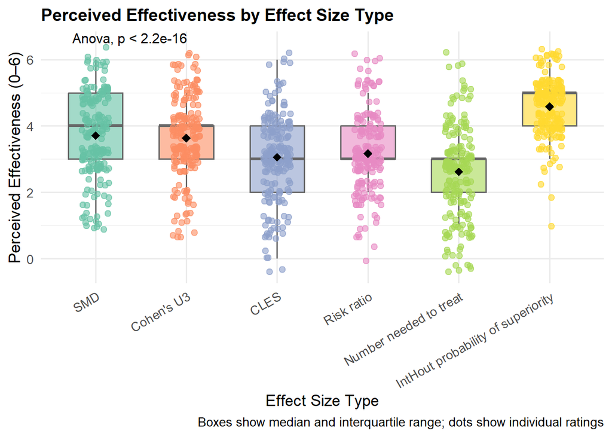

```r
ggplot(rq2_df, aes(x = group, y = effectiveness_cont, fill = group)) +
  geom_boxplot(alpha = 0.6, width = 0.6, outlier.shape = NA, color = "gray40") +
  geom_jitter(aes(color = group), width = 0.15, alpha = 0.6, size = 2) +
  stat_summary(fun = mean, geom = "point", shape = 18, size = 3, color = "black") +
  stat_compare_means(method = "anova", label.y = 6.5, size = 4) +
  scale_fill_brewer(palette = "Set2") +
  scale_color_brewer(palette = "Set2") +
  labs(
    x = "Effect Size Type",
    y = "Perceived Effectiveness (0–6)",
    title = "Perceived Effectiveness by Effect Size Type",
    caption = "Boxes show median and interquartile range; dots show individual ratings"
  ) +
  theme_minimal(base_size = 13) +
  theme(
    legend.position = "none",
    axis.text.x = element_text(angle = 30, hjust = 1),
    plot.title = element_text(face = "bold", size = 14)
  )
```

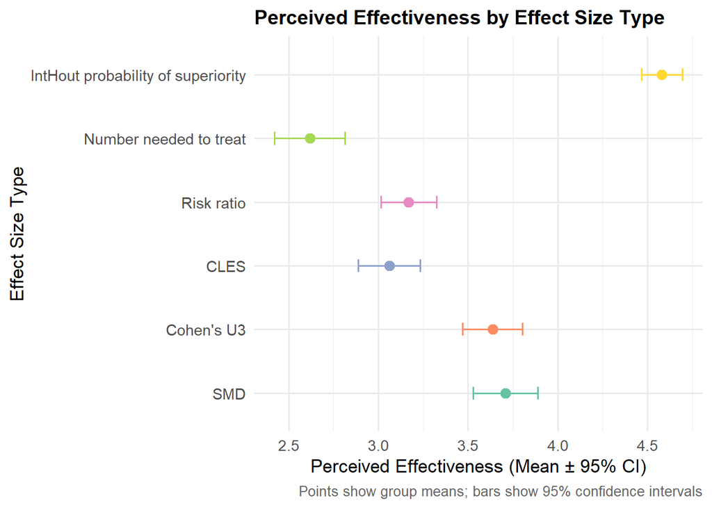

```r
# transposed dot
plot_df <- rq2_df %>%
  group_by(group) %>%
  summarise(
    mean = mean(effectiveness_cont, na.rm = TRUE),
    se   = sd(effectiveness_cont, na.rm = TRUE) / sqrt(sum(!is.na(effectiveness_cont))),
    n    = sum(!is.na(effectiveness_cont))
  ) %>%
  mutate(
    group = factor(group,
                   levels = c("SMD", "Cohen's U3", "CLES",
                              "Risk ratio", "Number needed to treat",
                              "IntHout probability of superiority"))
  )

ggplot(plot_df, aes(y = group, x = mean, color = group)) +
  geom_point(size = 3) +
  geom_errorbar(aes(xmin = mean - 1.96 * se, xmax = mean + 1.96 * se),
                width = 0.2, orientation = "y") +   # <-- fixed line
  scale_color_brewer(palette = "Set2") +
  labs(
    x = "Perceived Effectiveness (Mean ± 95% CI)",
    y = "Effect Size Type",
    title = "Perceived Effectiveness by Effect Size Type",
    caption = "Points show group means; bars show 95% confidence intervals"
  ) +
  theme_minimal(base_size = 13) +
  theme(
    legend.position = "none",
    axis.text.y = element_text(size = 11),
    plot.title = element_text(face = "bold", size = 14),
    plot.caption = element_text(size = 10, color = "gray40")
  )
```

### RQ3: How does participant comprehension of the precision of the effect vary by effect size presented?

Outcome: precision comprehension (`precision`) - Q: How precise are these findings? In other words, how sure can we be that the effect is XX? - Options: 0 (Not at all) - 6 (Very); 3 = Somewhat - Continuous score

ES Groups (based on the effect size the participant sees; `group`): - 1 = SMD - 2 = Cohen’s U3 - 3 = CLES - 4 = Risk ratio - 5 = Number needed to treat - 6 = IntHout probability of superiority (PSES)

Analysis plan: ANCOVA with Tukey adjustment for contrasts Covariates: - Numeracy level (1-9): `num_score` - Age (continuous variable): `age` - Sex (male/female): `sex` - Race/ethnicity (White, Mixed, Asian, Black and Other): `ethnicity_simplified`

```r
rq3_df <- full_td %>%
  select(pid, group, precision_cont, num_score, age, sex, ethnicity_simplified)
```

```r
# Updated analysis on 11/7/25 to get adjusted tukey mean comparisons
fit_rq3 <- lm(
  precision_cont ~ group + num_score + age + sex + ethnicity_simplified,
  data = rq3_df
)
summary(fit_rq3)
```

```
##
## Call:
## lm(formula = precision_cont ~ group + num_score + age + sex +
##     ethnicity_simplified, data = rq3_df)
##
## Residuals:
##     Min      1Q  Median      3Q     Max
## -4.2227 -0.8436  0.1091  0.9917  3.0914
##
## Coefficients:
##                                          Estimate Std. Error t value Pr(>|t|)
## (Intercept)                              3.878166   0.245733  15.782  < 2e-16
## groupCohen's U3                          0.092139   0.129127   0.714   0.4756
## groupCLES                               -0.119465   0.128956  -0.926   0.3544
## groupRisk ratio                          0.005036   0.128399   0.039   0.9687
## groupNumber needed to treat             -0.960151   0.130784  -7.342 3.94e-13
## groupIntHout probability of superiority -0.212559   0.128066  -1.660   0.0972
## num_score                                0.055682   0.025531   2.181   0.0294
## age                                     -0.004427   0.002179  -2.032   0.0424
## sexMale                                  0.078179   0.075339   1.038   0.2996
## ethnicity_simplifiedBlack                0.082257   0.193256   0.426   0.6705
## ethnicity_simplifiedMixed                0.159955   0.194572   0.822   0.4112
## ethnicity_simplifiedOther                0.292217   0.208272   1.403   0.1609
## ethnicity_simplifiedWhite               -0.048781   0.165614  -0.295   0.7684
##
## (Intercept)                             ***
## groupCohen's U3
## groupCLES
## groupRisk ratio
## groupNumber needed to treat             ***
## groupIntHout probability of superiority .
## num_score                               *
## age                                     *
## sexMale
## ethnicity_simplifiedBlack
## ethnicity_simplifiedMixed
## ethnicity_simplifiedOther
## ethnicity_simplifiedWhite
## ---
## Signif. codes:  0 '***' 0.001 '**' 0.01 '*' 0.05 '.' 0.1 ' ' 1
##
## Residual standard error: 1.275 on 1171 degrees of freedom
##   (5 observations deleted due to missingness)
## Multiple R-squared:  0.08182,    Adjusted R-squared:  0.07241
## F-statistic: 8.695 on 12 and 1171 DF,  p-value: 4.694e-16
```

```r
anova_rq3 <- car::Anova(fit_rq3, type = 2)
anova_rq3
```

```
## Anova Table (Type II tests)
##
## Response: precision_cont
##                       Sum Sq   Df F value  Pr(>F)
## group                 141.64    5 17.4255 < 2e-16 ***
## num_score               7.73    1  4.7567 0.02938 *
## age                     6.71    1  4.1290 0.04238 *
## sex                     1.75    1  1.0768 0.29963
## ethnicity_simplified   12.76    4  1.9629 0.09792 .
## Residuals            1903.72 1171
## ---
## Signif. codes:  0 '***' 0.001 '**' 0.01 '*' 0.05 '.' 0.1 ' ' 1
```

```r
emm_rq3 <- emmeans(fit_rq3, ~ group)

eta_sq_rq3 <- effectsize::eta_squared(anova_rq3, partial = FALSE, generalized = TRUE, ci = 0.95)
eta_sq_rq3
```

```
## # Effect Size for ANOVA (Type II)
##
## Parameter            | Eta2 (generalized) |       95% CI
## --------------------------------------------------------
## group                |               0.07 | [0.04, 1.00]
## num_score            |           4.05e-03 | [0.00, 1.00]
## age                  |           3.51e-03 | [0.00, 1.00]
## sex                  |           9.19e-04 | [0.00, 1.00]
## ethnicity_simplified |           6.66e-03 | [0.00, 1.00]
##
## - Observed variables: All
## - One-sided CIs: upper bound fixed at [1.00].
```

```r
pairs_rq3 <- pairs(emm_rq3, adjust = "tukey")

pairs_rq3_ci <- pairs(emm_rq3, adjust = "tukey") %>%
  summary(infer = TRUE)
pairs_rq3_ci
```

```
##  contrast                                                    estimate    SE
##  SMD - Cohen's U3                                            -0.09214 0.129
##  SMD - CLES                                                   0.11947 0.129
##  SMD - Risk ratio                                            -0.00504 0.128
##  SMD - Number needed to treat                                 0.96015 0.131
##  SMD - IntHout probability of superiority                     0.21256 0.128
##  Cohen's U3 - CLES                                            0.21160 0.128
##  Cohen's U3 - Risk ratio                                      0.08710 0.128
##  Cohen's U3 - Number needed to treat                          1.05229 0.130
##  Cohen's U3 - IntHout probability of superiority              0.30470 0.128
##  CLES - Risk ratio                                           -0.12450 0.128
##  CLES - Number needed to treat                                0.84069 0.130
##  CLES - IntHout probability of superiority                    0.09309 0.127
##  Risk ratio - Number needed to treat                          0.96519 0.130
##  Risk ratio - IntHout probability of superiority              0.21759 0.127
##  Number needed to treat - IntHout probability of superiority -0.74759 0.129
##    df lower.CL upper.CL t.ratio p.value
##  1171  -0.4607    0.276  -0.714  0.9803
##  1171  -0.2486    0.488   0.926  0.9398
##  1171  -0.3715    0.361  -0.039  1.0000
##  1171   0.5868    1.333   7.342  <.0001
##  1171  -0.1530    0.578   1.660  0.5589
##  1171  -0.1549    0.578   1.648  0.5668
##  1171  -0.2779    0.452   0.681  0.9840
##  1171   0.6802    1.424   8.072  <.0001
##  1171  -0.0595    0.669   2.388  0.1612
##  1171  -0.4898    0.241  -0.973  0.9265
##  1171   0.4695    1.212   6.464  <.0001
##  1171  -0.2708    0.457   0.730  0.9782
##  1171   0.5939    1.337   7.420  <.0001
##  1171  -0.1449    0.580   1.713  0.5231
##  1171  -1.1172   -0.378  -5.774  <.0001
##
## Results are averaged over the levels of: sex, ethnicity_simplified
## Confidence level used: 0.95
## Conf-level adjustment: tukey method for comparing a family of 6 estimates
## P value adjustment: tukey method for comparing a family of 6 estimates
```

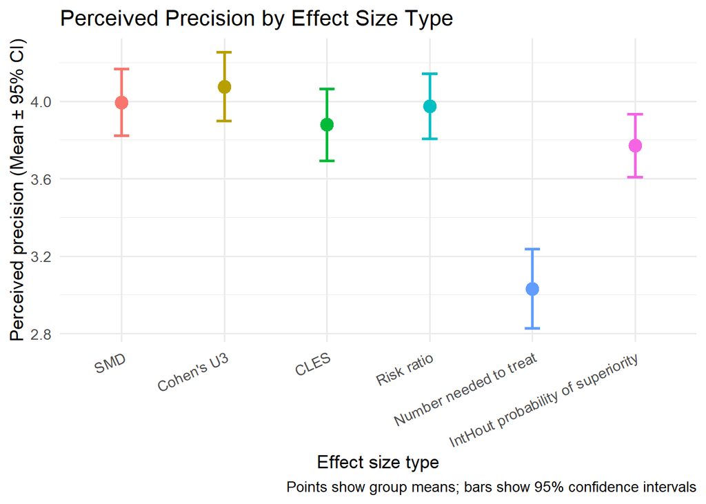

```r
# Point plot
# summarize
# summarize means + CIs
plot_df <- rq3_df %>%
  group_by(group) %>%
  summarise(
    mean = mean(precision_cont, na.rm = TRUE),
    se   = sd(precision_cont, na.rm = TRUE) / sqrt(sum(!is.na(precision_cont))),
    n    = sum(!is.na(precision_cont)),
    .groups = "drop"
  )

ggplot(plot_df, aes(x = group, y = mean, color = group)) +
  geom_point(size = 4) +
  geom_errorbar(aes(ymin = mean - 1.96*se, ymax = mean + 1.96*se),
                width = 0.15, linewidth = 1) +
  labs(
    x = "Effect size type",
    y = "Perceived precision (Mean ± 95% CI)",
    title = "Perceived Precision by Effect Size Type",
    caption = "Points show group means; bars show 95% confidence intervals"
  ) +
  theme_minimal(base_size = 13) +
  theme(
    legend.position = "none",
    axis.text.x = element_text(angle = 25, hjust = 1)
  )
```

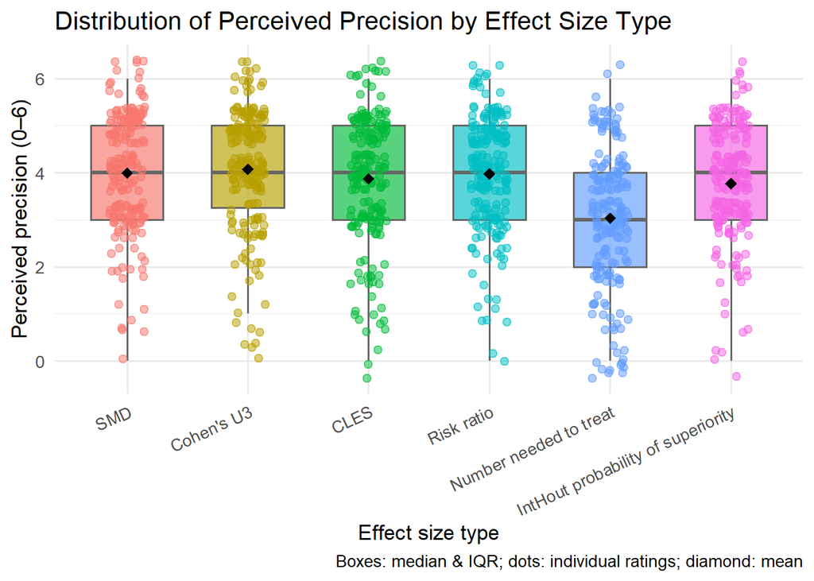

```r
# Boxplot with jitter
ggplot(rq3_df, aes(x = group, y = precision_cont, fill = group)) +
  geom_boxplot(alpha = 0.65, width = 0.6, outlier.shape = NA, color = "gray40") +
  geom_jitter(aes(color = group), width = 0.15, alpha = 0.5, size = 2) +
  stat_summary(fun = mean, geom = "point", shape = 18, size = 3, color = "black") +
  labs(
    x = "Effect size type",
    y = "Perceived precision (0–6)",
    title = "Distribution of Perceived Precision by Effect Size Type",
    caption = "Boxes: median & IQR; dots: individual ratings; diamond: mean"
  ) +
  theme_minimal(base_size = 13) +
  theme(
    legend.position = "none",
    axis.text.x = element_text(angle = 25, hjust = 1)
  )
```

### RQ4: How do participants rate the ease of 6 different domains?

Outcomes: 6 different domains: - Options: 0 (Strongly disagree) - 6 (Strongly agree); 3 = Neither - Continuous scores - Understandability (`understandable`): The information given about the programs is easy to understand.  
- Helpfulness (`helpful`): The information given about the programs is helpful to judge how effective the program was.  
- Actionable (`actionable`): The findings presented are actionable (I know what to do with them). - Concise (`concise`): The findings presented are concise (short and to the point). - Credible (`credible`): The findings presented are credible or trustworthy. - Recommendation (`recommendation`): I am likely to recommend that schools implement these programs.

ES Groups (based on the effect size the participant sees; `group`): - 1 = SMD - 2 = Cohen’s U3 - 3 = CLES - 4 = Risk ratio - 5 = Number needed to treat - 6 = IntHout probability of superiority (PSES)

Analysis plan: separate ANCOVA with Tukey adjustment for contrasts Covariates: - Numeracy level (1-9): `num_score` - Age (continuous variable): `age` - Sex (male/female): `sex` - Race/ethnicity (White, Mixed, Asian, Black and Other): `ethnicity_simplified`

#### Separate ANCOVA models per domain

```r
rq4_df <- full_td %>%
  select(pid, group, understandable, helpful, actionable, concise, credible, recommendation,
         num_score, age, sex, ethnicity_simplified, effectiveness_cont, precision_cont) %>%
  mutate(across(c(understandable, helpful, actionable, concise, credible, recommendation),
                ~ case_when(tolower(.) == "strongly disagree" ~ 0,
                            tolower(.) == "disagree" ~ 1,
                            tolower(.) == "somewhat disagree" ~ 2,
                            tolower(.) == "neither agree or disagree" ~ 3,
                            tolower(.) == "somewhat agree" ~ 4,
                            tolower(.) == "agree" ~ 5,
                            tolower(.) == "strongly agree" ~ 6,
                            TRUE ~ NA_real_)))
```

```r
# Updated 11/10/25 to run with adjusted Tukey correction

# UNDERSTANDABLE -----------------------------------

# LM model
fit_understandable <- lm(
  understandable ~ group + num_score + age + sex + ethnicity_simplified,
  data = rq4_df
)
summary(fit_understandable)
```

```
##
## Call:
## lm(formula = understandable ~ group + num_score + age + sex +
##     ethnicity_simplified, data = rq4_df)
##
## Residuals:
##     Min      1Q  Median      3Q     Max
## -4.6063 -0.7304  0.2358  0.9550  3.7228
##
## Coefficients:
##                                          Estimate Std. Error t value Pr(>|t|)
## (Intercept)                              3.831073   0.271099  14.132  < 2e-16
## groupCohen's U3                          0.683749   0.142457   4.800 1.79e-06
## groupCLES                                0.160102   0.142268   1.125 0.260670
## groupRisk ratio                          0.500598   0.141654   3.534 0.000425
## groupNumber needed to treat             -0.974341   0.144284  -6.753 2.28e-11
## groupIntHout probability of superiority  0.960359   0.141286   6.797 1.69e-11
## num_score                               -0.057211   0.028166  -2.031 0.042461
## age                                     -0.007367   0.002404  -3.065 0.002229
## sexMale                                  0.194542   0.083116   2.341 0.019420
## ethnicity_simplifiedBlack                0.250675   0.213205   1.176 0.239935
## ethnicity_simplifiedMixed                0.336119   0.214657   1.566 0.117656
## ethnicity_simplifiedOther                0.338724   0.229771   1.474 0.140702
## ethnicity_simplifiedWhite                0.155917   0.182710   0.853 0.393636
##
## (Intercept)                             ***
## groupCohen's U3                         ***
## groupCLES
## groupRisk ratio                         ***
## groupNumber needed to treat             ***
## groupIntHout probability of superiority ***
## num_score                               *
## age                                     **
## sexMale                                 *
## ethnicity_simplifiedBlack
## ethnicity_simplifiedMixed
## ethnicity_simplifiedOther
## ethnicity_simplifiedWhite
## ---
## Signif. codes:  0 '***' 0.001 '**' 0.01 '*' 0.05 '.' 0.1 ' ' 1
##
## Residual standard error: 1.407 on 1171 degrees of freedom
##   (5 observations deleted due to missingness)
## Multiple R-squared:  0.1712, Adjusted R-squared:  0.1627
## F-statistic: 20.16 on 12 and 1171 DF,  p-value: < 2.2e-16
```

```r
# Type II ANCOVA
anova_understandable <- car::Anova(fit_understandable, type = 2)
anova_understandable
```

```
## Anova Table (Type II tests)
##
## Response: understandable
##                       Sum Sq   Df F value    Pr(>F)
## group                 443.42    5 44.8200 < 2.2e-16 ***
## num_score               8.16    1  4.1257  0.042461 *
## age                    18.58    1  9.3925  0.002229 **
## sex                    10.84    1  5.4784  0.019420 *
## ethnicity_simplified    8.22    4  1.0389  0.385876
## Residuals            2317.03 1171
## ---
## Signif. codes:  0 '***' 0.001 '**' 0.01 '*' 0.05 '.' 0.1 ' ' 1
```

```r
# # Adjusted means (EMMs)
emm_understandable <- emmeans(fit_understandable, ~ group)
emm_understandable
```

```
##  group                              emmean    SE   df lower.CL upper.CL
##  SMD                                  3.53 0.109 1171     3.31     3.74
##  Cohen's U3                           4.21 0.109 1171     4.00     4.43
##  CLES                                 3.69 0.109 1171     3.47     3.90
##  Risk ratio                           4.03 0.109 1171     3.81     4.24
##  Number needed to treat               2.55 0.108 1171     2.34     2.77
##  IntHout probability of superiority   4.49 0.108 1171     4.28     4.70
##
## Results are averaged over the levels of: sex, ethnicity_simplified
## Confidence level used: 0.95
```

```r
# Eta-squared
eta_sq_understandable <- eta_squared(anova_understandable, partial = FALSE,   # gives generalized η²
                                     generalized = TRUE, ci = 0.95)
eta_sq_understandable
```

```
## # Effect Size for ANOVA (Type II)
##
## Parameter            | Eta2 (generalized) |       95% CI
## --------------------------------------------------------
## group                |               0.16 | [0.13, 1.00]
## num_score            |           3.51e-03 | [0.00, 1.00]
## age                  |           7.96e-03 | [0.00, 1.00]
## sex                  |           4.66e-03 | [0.00, 1.00]
## ethnicity_simplified |           3.54e-03 | [0.00, 1.00]
##
## - Observed variables: All
## - One-sided CIs: upper bound fixed at [1.00].
```

```r
# Tukey on adjusted means
pairs_understandable <- pairs(emm_understandable, adjust = "tukey") %>%
  summary(infer = TRUE)
pairs_understandable
```

```
##  contrast                                                    estimate    SE
##  SMD - Cohen's U3                                              -0.684 0.142
##  SMD - CLES                                                    -0.160 0.142
##  SMD - Risk ratio                                              -0.501 0.142
##  SMD - Number needed to treat                                   0.974 0.144
##  SMD - IntHout probability of superiority                      -0.960 0.141
##  Cohen's U3 - CLES                                              0.524 0.142
##  Cohen's U3 - Risk ratio                                        0.183 0.141
##  Cohen's U3 - Number needed to treat                            1.658 0.144
##  Cohen's U3 - IntHout probability of superiority               -0.277 0.141
##  CLES - Risk ratio                                             -0.340 0.141
##  CLES - Number needed to treat                                  1.134 0.143
##  CLES - IntHout probability of superiority                     -0.800 0.141
##  Risk ratio - Number needed to treat                            1.475 0.144
##  Risk ratio - IntHout probability of superiority               -0.460 0.140
##  Number needed to treat - IntHout probability of superiority   -1.935 0.143
##    df lower.CL upper.CL t.ratio p.value
##  1171   -1.090  -0.2771  -4.800  <.0001
##  1171   -0.566   0.2460  -1.125  0.8709
##  1171   -0.905  -0.0963  -3.534  0.0057
##  1171    0.562   1.3862   6.753  <.0001
##  1171   -1.364  -0.5571  -6.797  <.0001
##  1171    0.119   0.9280   3.696  0.0031
##  1171   -0.219   0.5858   1.298  0.7860
##  1171    1.248   2.0686  11.529  <.0001
##  1171   -0.678   0.1252  -1.965  0.3633
##  1171   -0.744   0.0625  -2.412  0.1529
##  1171    0.725   1.5440   7.907  <.0001
##  1171   -1.202  -0.3988  -5.690  <.0001
##  1171    1.065   1.8846  10.277  <.0001
##  1171   -0.860  -0.0599  -3.282  0.0135
##  1171   -2.342  -1.5270 -13.545  <.0001
##
## Results are averaged over the levels of: sex, ethnicity_simplified
## Confidence level used: 0.95
## Conf-level adjustment: tukey method for comparing a family of 6 estimates
## P value adjustment: tukey method for comparing a family of 6 estimates
```

```r
# HELPFUL -----------------------------------------------

fit_helpful <- lm(
  helpful ~ group + num_score + age + sex + ethnicity_simplified,
  data = rq4_df
)
summary(fit_helpful)
```

```
##
## Call:
## lm(formula = helpful ~ group + num_score + age + sex + ethnicity_simplified,
##     data = rq4_df)
##
## Residuals:
##     Min      1Q  Median      3Q     Max
## -4.6706 -0.6411  0.2404  0.9216  3.0070
##
## Coefficients:
##                                          Estimate Std. Error t value Pr(>|t|)
## (Intercept)                              3.968164   0.263277  15.072  < 2e-16
## groupCohen's U3                          0.424410   0.138346   3.068 0.002206
## groupCLES                               -0.156658   0.138163  -1.134 0.257087
## groupRisk ratio                          0.439826   0.137567   3.197 0.001425
## groupNumber needed to treat             -1.081441   0.140121  -7.718 2.52e-14
## groupIntHout probability of superiority  0.330296   0.137209   2.407 0.016227
## num_score                               -0.013412   0.027353  -0.490 0.624001
## age                                     -0.001147   0.002334  -0.491 0.623293
## sexMale                                  0.296630   0.080718   3.675 0.000249
## ethnicity_simplifiedBlack                0.129732   0.207054   0.627 0.531070
## ethnicity_simplifiedMixed               -0.031445   0.208464  -0.151 0.880125
## ethnicity_simplifiedOther                0.125672   0.223142   0.563 0.573413
## ethnicity_simplifiedWhite               -0.094574   0.177439  -0.533 0.594140
##
## (Intercept)                             ***
## groupCohen's U3                         **
## groupCLES
## groupRisk ratio                         **
## groupNumber needed to treat             ***
## groupIntHout probability of superiority *
## num_score
## age
## sexMale                                 ***
## ethnicity_simplifiedBlack
## ethnicity_simplifiedMixed
## ethnicity_simplifiedOther
## ethnicity_simplifiedWhite
## ---
## Signif. codes:  0 '***' 0.001 '**' 0.01 '*' 0.05 '.' 0.1 ' ' 1
##
## Residual standard error: 1.366 on 1171 degrees of freedom
##   (5 observations deleted due to missingness)
## Multiple R-squared:  0.1343, Adjusted R-squared:  0.1254
## F-statistic: 15.14 on 12 and 1171 DF,  p-value: < 2.2e-16
```

```r
anova_helpful <- car::Anova(fit_helpful, type = 2)
anova_helpful
```

```
## Anova Table (Type II tests)
##
## Response: helpful
##                       Sum Sq   Df F value    Pr(>F)
## group                 317.57    5 34.0349 < 2.2e-16 ***
## num_score               0.45    1  0.2404 0.6240006
## age                     0.45    1  0.2414 0.6232925
## sex                    25.20    1 13.5048 0.0002487 ***
## ethnicity_simplified    8.55    4  1.1454 0.3335571
## Residuals            2185.26 1171
## ---
## Signif. codes:  0 '***' 0.001 '**' 0.01 '*' 0.05 '.' 0.1 ' ' 1
```

```r
eta_sq_helpful <- effectsize::eta_squared(anova_helpful, partial = FALSE, generalized = TRUE, ci = 0.95)
eta_sq_helpful
```

```
## # Effect Size for ANOVA (Type II)
##
## Parameter            | Eta2 (generalized) |       95% CI
## --------------------------------------------------------
## group                |               0.13 | [0.10, 1.00]
## num_score            |           2.05e-04 | [0.00, 1.00]
## age                  |           2.06e-04 | [0.00, 1.00]
## sex                  |               0.01 | [0.00, 1.00]
## ethnicity_simplified |           3.90e-03 | [0.00, 1.00]
##
## - Observed variables: All
## - One-sided CIs: upper bound fixed at [1.00].
```

```r
emm_helpful <- emmeans(fit_helpful, ~ group)
 emm_helpful
```

```
##  group                              emmean    SE   df lower.CL upper.CL
##  SMD                                  4.02 0.106 1171     3.82     4.23
##  Cohen's U3                           4.45 0.106 1171     4.24     4.66
##  CLES                                 3.87 0.106 1171     3.66     4.08
##  Risk ratio                           4.46 0.106 1171     4.26     4.67
##  Number needed to treat               2.94 0.105 1171     2.74     3.15
##  IntHout probability of superiority   4.36 0.105 1171     4.15     4.56
##
## Results are averaged over the levels of: sex, ethnicity_simplified
## Confidence level used: 0.95
```

```r
pairs_helpful <- pairs(emm_helpful, adjust = "tukey") %>%
  summary(infer = TRUE)
pairs_helpful
```

```
##  contrast                                                    estimate    SE
##  SMD - Cohen's U3                                             -0.4244 0.138
##  SMD - CLES                                                    0.1567 0.138
##  SMD - Risk ratio                                             -0.4398 0.138
##  SMD - Number needed to treat                                  1.0814 0.140
##  SMD - IntHout probability of superiority                     -0.3303 0.137
##  Cohen's U3 - CLES                                             0.5811 0.138
##  Cohen's U3 - Risk ratio                                      -0.0154 0.137
##  Cohen's U3 - Number needed to treat                           1.5059 0.140
##  Cohen's U3 - IntHout probability of superiority               0.0941 0.137
##  CLES - Risk ratio                                            -0.5965 0.137
##  CLES - Number needed to treat                                 0.9248 0.139
##  CLES - IntHout probability of superiority                    -0.4870 0.137
##  Risk ratio - Number needed to treat                           1.5213 0.139
##  Risk ratio - IntHout probability of superiority               0.1095 0.136
##  Number needed to treat - IntHout probability of superiority  -1.4117 0.139
##    df lower.CL upper.CL t.ratio p.value
##  1171   -0.819  -0.0295  -3.068  0.0268
##  1171   -0.238   0.5510   1.134  0.8673
##  1171   -0.833  -0.0472  -3.197  0.0178
##  1171    0.681   1.4814   7.718  <.0001
##  1171   -0.722   0.0614  -2.407  0.1545
##  1171    0.188   0.9738   4.224  0.0004
##  1171   -0.406   0.3756  -0.113  1.0000
##  1171    1.107   1.9045  10.782  <.0001
##  1171   -0.296   0.4844   0.688  0.9833
##  1171   -0.988  -0.2051  -4.350  0.0002
##  1171    0.527   1.3225   6.637  <.0001
##  1171   -0.877  -0.0971  -3.565  0.0051
##  1171    1.123   1.9191  10.915  <.0001
##  1171   -0.279   0.4979   0.805  0.9666
##  1171   -1.808  -1.0158 -10.177  <.0001
##
## Results are averaged over the levels of: sex, ethnicity_simplified
## Confidence level used: 0.95
## Conf-level adjustment: tukey method for comparing a family of 6 estimates
## P value adjustment: tukey method for comparing a family of 6 estimates
```

```r
# ACTIONABLE ---------------------------------------------

fit_actionable <- lm(
  actionable ~ group + num_score + age + sex + ethnicity_simplified,
  data = rq4_df
)
summary(fit_actionable)
```

```
##
## Call:
## lm(formula = actionable ~ group + num_score + age + sex + ethnicity_simplified,
##     data = rq4_df)
##
## Residuals:
##     Min      1Q  Median      3Q     Max
## -4.1894 -1.0300  0.2511  1.1916  3.3837
##
## Coefficients:
##                                           Estimate Std. Error t value Pr(>|t|)
## (Intercept)                              3.3520835  0.2898184  11.566  < 2e-16
## groupCohen's U3                          0.4524246  0.1522932   2.971 0.003031
## groupCLES                                0.0960598  0.1520916   0.632 0.527777
## groupRisk ratio                          0.5552444  0.1514347   3.667 0.000257
## groupNumber needed to treat             -0.5721036  0.1542466  -3.709 0.000218
## groupIntHout probability of superiority  0.7544716  0.1510413   4.995 6.77e-07
## num_score                               -0.0699334  0.0301110  -2.323 0.020376
## age                                     -0.0005192  0.0025697  -0.202 0.839910
## sexMale                                  0.2786608  0.0888553   3.136 0.001755
## ethnicity_simplifiedBlack                0.3086835  0.2279271   1.354 0.175899
## ethnicity_simplifiedMixed                0.3268844  0.2294788   1.424 0.154578
## ethnicity_simplifiedOther                0.1170025  0.2456369   0.476 0.633933
## ethnicity_simplifiedWhite               -0.0745103  0.1953262  -0.381 0.702927
##
## (Intercept)                             ***
## groupCohen's U3                         **
## groupCLES
## groupRisk ratio                         ***
## groupNumber needed to treat             ***
## groupIntHout probability of superiority ***
## num_score                               *
## age
## sexMale                                 **
## ethnicity_simplifiedBlack
## ethnicity_simplifiedMixed
## ethnicity_simplifiedOther
## ethnicity_simplifiedWhite
## ---
## Signif. codes:  0 '***' 0.001 '**' 0.01 '*' 0.05 '.' 0.1 ' ' 1
##
## Residual standard error: 1.504 on 1171 degrees of freedom
##   (5 observations deleted due to missingness)
## Multiple R-squared:  0.09055,    Adjusted R-squared:  0.08123
## F-statistic: 9.716 on 12 and 1171 DF,  p-value: < 2.2e-16
```

```r
anova_actionable <- car::Anova(fit_actionable, type = 2)
anova_actionable
```

```
## Anova Table (Type II tests)
##
## Response: actionable
##                       Sum Sq   Df F value    Pr(>F)
## group                 219.42    5 19.4061 < 2.2e-16 ***
## num_score              12.20    1  5.3941  0.020376 *
## age                     0.09    1  0.0408  0.839910
## sex                    22.24    1  9.8352  0.001755 **
## ethnicity_simplified   29.94    4  3.3096  0.010450 *
## Residuals            2648.06 1171
## ---
## Signif. codes:  0 '***' 0.001 '**' 0.01 '*' 0.05 '.' 0.1 ' ' 1
```

```r
eta_sq_actionable <- effectsize::eta_squared(anova_actionable, partial = FALSE, generalized = TRUE, ci = 0.95)
eta_sq_actionable
```

```
## # Effect Size for ANOVA (Type II)
##
## Parameter            | Eta2 (generalized) |       95% CI
## --------------------------------------------------------
## group                |               0.08 | [0.05, 1.00]
## num_score            |           4.59e-03 | [0.00, 1.00]
## age                  |           3.49e-05 | [0.00, 1.00]
## sex                  |           8.33e-03 | [0.00, 1.00]
## ethnicity_simplified |               0.01 | [0.00, 1.00]
##
## - Observed variables: All
## - One-sided CIs: upper bound fixed at [1.00].
```

```r
emm_actionable <- emmeans(fit_actionable, ~ group)
 emm_actionable
```

```
##  group                              emmean    SE   df lower.CL upper.CL
##  SMD                                  3.27 0.117 1171     3.04     3.50
##  Cohen's U3                           3.72 0.117 1171     3.49     3.95
##  CLES                                 3.37 0.117 1171     3.14     3.60
##  Risk ratio                           3.83 0.116 1171     3.60     4.05
##  Number needed to treat               2.70 0.116 1171     2.47     2.93
##  IntHout probability of superiority   4.03 0.116 1171     3.80     4.25
##
## Results are averaged over the levels of: sex, ethnicity_simplified
## Confidence level used: 0.95
```

```r
pairs_actionable <- pairs(emm_actionable, adjust = "tukey") %>%
  summary(infer = TRUE)
pairs_actionable
```

```
##  contrast                                                    estimate    SE
##  SMD - Cohen's U3                                             -0.4524 0.152
##  SMD - CLES                                                   -0.0961 0.152
##  SMD - Risk ratio                                             -0.5552 0.151
##  SMD - Number needed to treat                                  0.5721 0.154
##  SMD - IntHout probability of superiority                     -0.7545 0.151
##  Cohen's U3 - CLES                                             0.3564 0.151
##  Cohen's U3 - Risk ratio                                      -0.1028 0.151
##  Cohen's U3 - Number needed to treat                           1.0245 0.154
##  Cohen's U3 - IntHout probability of superiority              -0.3020 0.150
##  CLES - Risk ratio                                            -0.4592 0.151
##  CLES - Number needed to treat                                 0.6682 0.153
##  CLES - IntHout probability of superiority                    -0.6584 0.150
##  Risk ratio - Number needed to treat                           1.1273 0.153
##  Risk ratio - IntHout probability of superiority              -0.1992 0.150
##  Number needed to treat - IntHout probability of superiority  -1.3266 0.153
##    df lower.CL upper.CL t.ratio p.value
##  1171  -0.8871  -0.0177  -2.971  0.0358
##  1171  -0.5302   0.3381  -0.632  0.9887
##  1171  -0.9875  -0.1230  -3.667  0.0035
##  1171   0.1318   1.0124   3.709  0.0030
##  1171  -1.1856  -0.3233  -4.995  <.0001
##  1171  -0.0759   0.7887   2.353  0.1740
##  1171  -0.5333   0.3276  -0.682  0.9840
##  1171   0.5857   1.4634   6.664  <.0001
##  1171  -0.7316   0.1275  -2.007  0.3388
##  1171  -0.8900  -0.0284  -3.042  0.0289
##  1171   0.2304   1.1060   4.356  0.0002
##  1171  -1.0876  -0.2292  -4.379  0.0002
##  1171   0.6894   1.5653   7.348  <.0001
##  1171  -0.6268   0.2283  -1.330  0.7682
##  1171  -1.7624  -0.8907  -8.688  <.0001
##
## Results are averaged over the levels of: sex, ethnicity_simplified
## Confidence level used: 0.95
## Conf-level adjustment: tukey method for comparing a family of 6 estimates
## P value adjustment: tukey method for comparing a family of 6 estimates
```

```r
# race
emm_actionable_race <- emmeans(fit_actionable, ~ ethnicity_simplified)
 emm_actionable_race
```

```
##  ethnicity_simplified emmean     SE   df lower.CL upper.CL
##  Asian                  3.35 0.1870 1171     2.98     3.72
##  Black                  3.66 0.1280 1171     3.41     3.91
##  Mixed                  3.68 0.1350 1171     3.41     3.94
##  Other                  3.47 0.1600 1171     3.15     3.78
##  White                  3.28 0.0551 1171     3.17     3.38
##
## Results are averaged over the levels of: group, sex
## Confidence level used: 0.95
```

```r
pairs_actionable_race <- pairs(emm_actionable_race, adjust = "tukey") %>%
  summary(infer = TRUE)
pairs_actionable_race
```

```
##  contrast      estimate    SE   df  lower.CL upper.CL t.ratio p.value
##  Asian - Black  -0.3087 0.228 1171 -0.931388    0.314  -1.354  0.6571
##  Asian - Mixed  -0.3269 0.229 1171 -0.953828    0.300  -1.424  0.6119
##  Asian - Other  -0.1170 0.246 1171 -0.788090    0.554  -0.476  0.9895
##  Asian - White   0.0745 0.195 1171 -0.459127    0.608   0.381  0.9955
##  Black - Mixed  -0.0182 0.186 1171 -0.525667    0.489  -0.098  1.0000
##  Black - Other   0.1917 0.204 1171 -0.365005    0.748   0.941  0.8810
##  Black - White   0.3832 0.140 1171  0.000425    0.766   2.735  0.0496
##  Mixed - Other   0.2099 0.208 1171 -0.357194    0.777   1.011  0.8503
##  Mixed - White   0.4014 0.146 1171  0.002429    0.800   2.749  0.0478
##  Other - White   0.1915 0.170 1171 -0.271578    0.655   1.130  0.7907
##
## Results are averaged over the levels of: group, sex
## Confidence level used: 0.95
## Conf-level adjustment: tukey method for comparing a family of 5 estimates
## P value adjustment: tukey method for comparing a family of 5 estimates
```

```r
# CONCISE -------------------------------------------------

fit_concise <- lm(
  concise ~ group + num_score + age + sex + ethnicity_simplified,
  data = rq4_df
)
summary(fit_concise)
```

```
##
## Call:
## lm(formula = concise ~ group + num_score + age + sex + ethnicity_simplified,
##     data = rq4_df)
##
## Residuals:
##     Min      1Q  Median      3Q     Max
## -4.8410 -0.6156  0.2192  0.8767  2.6806
##
## Coefficients:
##                                           Estimate Std. Error t value Pr(>|t|)
## (Intercept)                              4.3910430  0.2368658  18.538  < 2e-16
## groupCohen's U3                          0.3550682  0.1244678   2.853 0.004411
## groupCLES                               -0.0826230  0.1243031  -0.665 0.506380
## groupRisk ratio                          0.1883142  0.1237661   1.522 0.128396
## groupNumber needed to treat             -0.8437621  0.1260643  -6.693 3.38e-11
## groupIntHout probability of superiority  0.4188011  0.1234446   3.393 0.000715
## num_score                                0.0746715  0.0246094   3.034 0.002464
## age                                     -0.0075297  0.0021002  -3.585 0.000351
## sexMale                                  0.0007787  0.0726206   0.011 0.991447
## ethnicity_simplifiedBlack                0.1423931  0.1862827   0.764 0.444787
## ethnicity_simplifiedMixed                0.1077700  0.1875508   0.575 0.565660
## ethnicity_simplifiedOther                0.1766746  0.2007568   0.880 0.379016
## ethnicity_simplifiedWhite                0.0971900  0.1596383   0.609 0.542766
##
## (Intercept)                             ***
## groupCohen's U3                         **
## groupCLES
## groupRisk ratio
## groupNumber needed to treat             ***
## groupIntHout probability of superiority ***
## num_score                               **
## age                                     ***
## sexMale
## ethnicity_simplifiedBlack
## ethnicity_simplifiedMixed
## ethnicity_simplifiedOther
## ethnicity_simplifiedWhite
## ---
## Signif. codes:  0 '***' 0.001 '**' 0.01 '*' 0.05 '.' 0.1 ' ' 1
##
## Residual standard error: 1.229 on 1171 degrees of freedom
##   (5 observations deleted due to missingness)
## Multiple R-squared:  0.1173, Adjusted R-squared:  0.1083
## F-statistic: 12.97 on 12 and 1171 DF,  p-value: < 2.2e-16
```

```r
anova_concise <- car::Anova(fit_concise, type = 2)
anova_concise
```

```
## Anova Table (Type II tests)
##
## Response: concise
##                       Sum Sq   Df F value    Pr(>F)
## group                 200.56    5 26.5548 < 2.2e-16 ***
## num_score              13.91    1  9.2068 0.0024644 **
## age                    19.42    1 12.8541 0.0003506 ***
## sex                     0.00    1  0.0001 0.9914466
## ethnicity_simplified    1.39    4  0.2304 0.9213728
## Residuals            1768.81 1171
## ---
## Signif. codes:  0 '***' 0.001 '**' 0.01 '*' 0.05 '.' 0.1 ' ' 1
```

```r
eta_sq_concise <- effectsize::eta_squared(anova_concise, partial = FALSE, generalized = TRUE, ci = 0.95)
eta_sq_concise
```

```
## # Effect Size for ANOVA (Type II)
##
## Parameter            | Eta2 (generalized) |       95% CI
## --------------------------------------------------------
## group                |               0.10 | [0.07, 1.00]
## num_score            |           7.80e-03 | [0.00, 1.00]
## age                  |               0.01 | [0.00, 1.00]
## sex                  |           9.82e-08 | [0.00, 1.00]
## ethnicity_simplified |           7.86e-04 | [0.00, 1.00]
##
## - Observed variables: All
## - One-sided CIs: upper bound fixed at [1.00].
```

```r
emm_concise <- emmeans(fit_concise, ~ group)
 emm_concise
```

```
##  group                              emmean     SE   df lower.CL upper.CL
##  SMD                                  4.50 0.0956 1171     4.31     4.68
##  Cohen's U3                           4.85 0.0957 1171     4.66     5.04
##  CLES                                 4.41 0.0952 1171     4.23     4.60
##  Risk ratio                           4.69 0.0951 1171     4.50     4.87
##  Number needed to treat               3.65 0.0945 1171     3.47     3.84
##  IntHout probability of superiority   4.92 0.0945 1171     4.73     5.10
##
## Results are averaged over the levels of: sex, ethnicity_simplified
## Confidence level used: 0.95
```

```r
pairs_concise <- pairs(emm_concise, adjust = "tukey") %>%
  summary(infer = TRUE)
pairs_concise
```

```
##  contrast                                                    estimate    SE
##  SMD - Cohen's U3                                             -0.3551 0.124
##  SMD - CLES                                                    0.0826 0.124
##  SMD - Risk ratio                                             -0.1883 0.124
##  SMD - Number needed to treat                                  0.8438 0.126
##  SMD - IntHout probability of superiority                     -0.4188 0.123
##  Cohen's U3 - CLES                                             0.4377 0.124
##  Cohen's U3 - Risk ratio                                       0.1668 0.123
##  Cohen's U3 - Number needed to treat                           1.1988 0.126
##  Cohen's U3 - IntHout probability of superiority              -0.0637 0.123
##  CLES - Risk ratio                                            -0.2709 0.123
##  CLES - Number needed to treat                                 0.7611 0.125
##  CLES - IntHout probability of superiority                    -0.5014 0.123
##  Risk ratio - Number needed to treat                           1.0321 0.125
##  Risk ratio - IntHout probability of superiority              -0.2305 0.122
##  Number needed to treat - IntHout probability of superiority  -1.2626 0.125
##    df lower.CL  upper.CL t.ratio p.value
##  1171  -0.7104  0.000218  -2.853  0.0502
##  1171  -0.2722  0.437439   0.665  0.9857
##  1171  -0.5416  0.164969  -1.522  0.6504
##  1171   0.4839  1.203605   6.693  <.0001
##  1171  -0.7712 -0.066436  -3.393  0.0093
##  1171   0.0844  0.791003   3.536  0.0056
##  1171  -0.1850  0.518543   1.353  0.7550
##  1171   0.8402  1.557500   9.541  <.0001
##  1171  -0.4148  0.287357  -0.518  0.9955
##  1171  -0.6231  0.081180  -2.196  0.2401
##  1171   0.4033  1.118957   6.072  <.0001
##  1171  -0.8522 -0.150640  -4.080  0.0007
##  1171   0.6742  1.390002   8.231  <.0001
##  1171  -0.5799  0.118924  -1.883  0.4132
##  1171  -1.6188 -0.906337 -10.117  <.0001
##
## Results are averaged over the levels of: sex, ethnicity_simplified
## Confidence level used: 0.95
## Conf-level adjustment: tukey method for comparing a family of 6 estimates
## P value adjustment: tukey method for comparing a family of 6 estimates
```

```r
# CREDIBLE -------------------------------------------------------

fit_credible <- lm(
  credible ~ group + num_score + age + sex + ethnicity_simplified,
  data = rq4_df
)
summary(fit_credible)
```

```
##
## Call:
## lm(formula = credible ~ group + num_score + age + sex + ethnicity_simplified,
##     data = rq4_df)
##
## Residuals:
##     Min      1Q  Median      3Q     Max
## -4.5539 -0.5444 -0.0671  0.7782  2.8803
##
## Coefficients:
##                                          Estimate Std. Error t value Pr(>|t|)
## (Intercept)                              3.969455   0.217577  18.244  < 2e-16
## groupCohen's U3                          0.085812   0.114332   0.751   0.4531
## groupCLES                                0.002404   0.114180   0.021   0.9832
## groupRisk ratio                          0.233375   0.113687   2.053   0.0403
## groupNumber needed to treat             -0.719981   0.115798  -6.218 7.01e-10
## groupIntHout probability of superiority  0.175647   0.113392   1.549   0.1216
## num_score                                0.055410   0.022605   2.451   0.0144
## age                                     -0.003606   0.001929  -1.869   0.0618
## sexMale                                  0.073929   0.066707   1.108   0.2680
## ethnicity_simplifiedBlack                0.071951   0.171113   0.420   0.6742
## ethnicity_simplifiedMixed                0.144341   0.172278   0.838   0.4023
## ethnicity_simplifiedOther                0.076922   0.184408   0.417   0.6767
## ethnicity_simplifiedWhite               -0.013413   0.146638  -0.091   0.9271
##
## (Intercept)                             ***
## groupCohen's U3
## groupCLES
## groupRisk ratio                         *
## groupNumber needed to treat             ***
## groupIntHout probability of superiority
## num_score                               *
## age                                     .
## sexMale
## ethnicity_simplifiedBlack
## ethnicity_simplifiedMixed
## ethnicity_simplifiedOther
## ethnicity_simplifiedWhite
## ---
## Signif. codes:  0 '***' 0.001 '**' 0.01 '*' 0.05 '.' 0.1 ' ' 1
##
## Residual standard error: 1.129 on 1171 degrees of freedom
##   (5 observations deleted due to missingness)
## Multiple R-squared:  0.08062,    Adjusted R-squared:  0.0712
## F-statistic: 8.558 on 12 and 1171 DF,  p-value: 9.339e-16
```

```r
anova_credible <- car::Anova(fit_credible, type = 2)
anova_credible
```

```
## Anova Table (Type II tests)
##
## Response: credible
##                       Sum Sq   Df F value  Pr(>F)
## group                 113.79    5 17.8557 < 2e-16 ***
## num_score               7.66    1  6.0084 0.01438 *
## age                     4.45    1  3.4941 0.06184 .
## sex                     1.57    1  1.2283 0.26797
## ethnicity_simplified    3.37    4  0.6611 0.61909
## Residuals            1492.45 1171
## ---
## Signif. codes:  0 '***' 0.001 '**' 0.01 '*' 0.05 '.' 0.1 ' ' 1
```

```r
eta_sq_credible <- effectsize::eta_squared(anova_credible, partial = FALSE, generalized = TRUE, ci = 0.95)
eta_sq_credible
```

```
## # Effect Size for ANOVA (Type II)
##
## Parameter            | Eta2 (generalized) |       95% CI
## --------------------------------------------------------
## group                |               0.07 | [0.05, 1.00]
## num_score            |           5.10e-03 | [0.00, 1.00]
## age                  |           2.97e-03 | [0.00, 1.00]
## sex                  |           1.05e-03 | [0.00, 1.00]
## ethnicity_simplified |           2.25e-03 | [0.00, 1.00]
##
## - Observed variables: All
## - One-sided CIs: upper bound fixed at [1.00].
```

```r
emm_credible <- emmeans(fit_credible, ~ group)
 emm_credible
```

```
##  group                              emmean     SE   df lower.CL upper.CL
##  SMD                                  4.16 0.0878 1171     3.98     4.33
##  Cohen's U3                           4.24 0.0879 1171     4.07     4.41
##  CLES                                 4.16 0.0875 1171     3.99     4.33
##  Risk ratio                           4.39 0.0873 1171     4.22     4.56
##  Number needed to treat               3.44 0.0868 1171     3.27     3.61
##  IntHout probability of superiority   4.33 0.0868 1171     4.16     4.50
##
## Results are averaged over the levels of: sex, ethnicity_simplified
## Confidence level used: 0.95
```

```r
pairs_credible <- pairs(emm_credible, adjust = "tukey") %>%
  summary(infer = TRUE)
pairs_credible
```

```
##  contrast                                                    estimate    SE
##  SMD - Cohen's U3                                             -0.0858 0.114
##  SMD - CLES                                                   -0.0024 0.114
##  SMD - Risk ratio                                             -0.2334 0.114
##  SMD - Number needed to treat                                  0.7200 0.116
##  SMD - IntHout probability of superiority                     -0.1756 0.113
##  Cohen's U3 - CLES                                             0.0834 0.114
##  Cohen's U3 - Risk ratio                                      -0.1476 0.113
##  Cohen's U3 - Number needed to treat                           0.8058 0.115
##  Cohen's U3 - IntHout probability of superiority              -0.0898 0.113
##  CLES - Risk ratio                                            -0.2310 0.113
##  CLES - Number needed to treat                                 0.7224 0.115
##  CLES - IntHout probability of superiority                    -0.1732 0.113
##  Risk ratio - Number needed to treat                           0.9534 0.115
##  Risk ratio - IntHout probability of superiority               0.0577 0.112
##  Number needed to treat - IntHout probability of superiority  -0.8956 0.115
##    df lower.CL upper.CL t.ratio p.value
##  1171   -0.412   0.2405  -0.751  0.9754
##  1171   -0.328   0.3235  -0.021  1.0000
##  1171   -0.558   0.0911  -2.053  0.3132
##  1171    0.389   1.0505   6.218  <.0001
##  1171   -0.499   0.1480  -1.549  0.6324
##  1171   -0.241   0.4079   0.734  0.9778
##  1171   -0.471   0.1756  -1.303  0.7832
##  1171    0.476   1.1353   6.981  <.0001
##  1171   -0.412   0.2327  -0.795  0.9684
##  1171   -0.554   0.0925  -2.038  0.3211
##  1171    0.394   1.0511   6.274  <.0001
##  1171   -0.495   0.1490  -1.535  0.6418
##  1171    0.625   1.2821   8.277  <.0001
##  1171   -0.263   0.3787   0.513  0.9957
##  1171   -1.223  -0.5684  -7.813  <.0001
##
## Results are averaged over the levels of: sex, ethnicity_simplified
## Confidence level used: 0.95
## Conf-level adjustment: tukey method for comparing a family of 6 estimates
## P value adjustment: tukey method for comparing a family of 6 estimates
```

```r
# RECOMMENDED ---------------------------------------------------

fit_recommendation <- lm(
  recommendation ~ group + num_score + age + sex + ethnicity_simplified,
  data = rq4_df
)

summary(fit_recommendation)
```

```
##
## Call:
## lm(formula = recommendation ~ group + num_score + age + sex +
##     ethnicity_simplified, data = rq4_df)
##
## Residuals:
##     Min      1Q  Median      3Q     Max
## -4.5777 -0.8020  0.1505  0.9767  3.3058
##
## Coefficients:
##                                          Estimate Std. Error t value Pr(>|t|)
## (Intercept)                              4.854836   0.264753  18.337  < 2e-16
## groupCohen's U3                         -0.257787   0.139122  -1.853  0.06414
## groupCLES                               -0.633537   0.138938  -4.560 5.66e-06
## groupRisk ratio                         -0.074186   0.138338  -0.536  0.59188
## groupNumber needed to treat             -1.369431   0.140906  -9.719  < 2e-16
## groupIntHout probability of superiority  0.400526   0.137978   2.903  0.00377
## num_score                               -0.065986   0.027507  -2.399  0.01660
## age                                     -0.009781   0.002347  -4.167 3.32e-05
## sexMale                                 -0.034214   0.081170  -0.422  0.67346
## ethnicity_simplifiedBlack                0.271377   0.208214   1.303  0.19271
## ethnicity_simplifiedMixed                0.286748   0.209632   1.368  0.17162
## ethnicity_simplifiedOther                0.113544   0.224393   0.506  0.61295
## ethnicity_simplifiedWhite                0.066898   0.178433   0.375  0.70779
##
## (Intercept)                             ***
## groupCohen's U3                         .
## groupCLES                               ***
## groupRisk ratio
## groupNumber needed to treat             ***
## groupIntHout probability of superiority **
## num_score                               *
## age                                     ***
## sexMale
## ethnicity_simplifiedBlack
## ethnicity_simplifiedMixed
## ethnicity_simplifiedOther
## ethnicity_simplifiedWhite
## ---
## Signif. codes:  0 '***' 0.001 '**' 0.01 '*' 0.05 '.' 0.1 ' ' 1
##
## Residual standard error: 1.374 on 1171 degrees of freedom
##   (5 observations deleted due to missingness)
## Multiple R-squared:  0.1561, Adjusted R-squared:  0.1475
## F-statistic: 18.06 on 12 and 1171 DF,  p-value: < 2.2e-16
```

```r
anova_recommendation <- car::Anova(fit_recommendation, type = 2)
anova_recommendation
```

```
## Anova Table (Type II tests)
##
## Response: recommendation
##                       Sum Sq   Df F value    Pr(>F)
## group                 361.20    5 38.2807 < 2.2e-16 ***
## num_score              10.86    1  5.7546    0.0166 *
## age                    32.76    1 17.3601  3.32e-05 ***
## sex                     0.34    1  0.1777    0.6735
## ethnicity_simplified    9.52    4  1.2609    0.2835
## Residuals            2209.82 1171
## ---
## Signif. codes:  0 '***' 0.001 '**' 0.01 '*' 0.05 '.' 0.1 ' ' 1
```

```r
eta_sq_recommendation <- effectsize::eta_squared(anova_recommendation, partial = FALSE, generalized = TRUE, ci = 0.95)
eta_sq_recommendation
```

```
## # Effect Size for ANOVA (Type II)
##
## Parameter            | Eta2 (generalized) |       95% CI
## --------------------------------------------------------
## group                |               0.14 | [0.11, 1.00]
## num_score            |           4.89e-03 | [0.00, 1.00]
## age                  |               0.01 | [0.01, 1.00]
## sex                  |           1.52e-04 | [0.00, 1.00]
## ethnicity_simplified |           4.29e-03 | [0.00, 1.00]
##
## - Observed variables: All
## - One-sided CIs: upper bound fixed at [1.00].
```

```r
emm_recommendation <- emmeans(fit_recommendation, ~ group)
 emm_recommendation
```

```
##  group                              emmean    SE   df lower.CL upper.CL
##  SMD                                  4.21 0.107 1171     4.00     4.42
##  Cohen's U3                           3.96 0.107 1171     3.75     4.17
##  CLES                                 3.58 0.106 1171     3.37     3.79
##  Risk ratio                           4.14 0.106 1171     3.93     4.35
##  Number needed to treat               2.84 0.106 1171     2.64     3.05
##  IntHout probability of superiority   4.61 0.106 1171     4.41     4.82
##
## Results are averaged over the levels of: sex, ethnicity_simplified
## Confidence level used: 0.95
```

```r
pairs_recommendation <- pairs(emm_recommendation, adjust = "tukey") %>%
  summary(infer = TRUE)
pairs_recommendation
```

```
##  contrast                                                    estimate    SE
##  SMD - Cohen's U3                                              0.2578 0.139
##  SMD - CLES                                                    0.6335 0.139
##  SMD - Risk ratio                                              0.0742 0.138
##  SMD - Number needed to treat                                  1.3694 0.141
##  SMD - IntHout probability of superiority                     -0.4005 0.138
##  Cohen's U3 - CLES                                             0.3758 0.138
##  Cohen's U3 - Risk ratio                                      -0.1836 0.138
##  Cohen's U3 - Number needed to treat                           1.1116 0.140
##  Cohen's U3 - IntHout probability of superiority              -0.6583 0.137
##  CLES - Risk ratio                                            -0.5594 0.138
##  CLES - Number needed to treat                                 0.7359 0.140
##  CLES - IntHout probability of superiority                    -1.0341 0.137
##  Risk ratio - Number needed to treat                           1.2952 0.140
##  Risk ratio - IntHout probability of superiority              -0.4747 0.137
##  Number needed to treat - IntHout probability of superiority  -1.7700 0.139
##    df lower.CL upper.CL t.ratio p.value
##  1171  -0.1393  0.65490   1.853  0.4321
##  1171   0.2369  1.03013   4.560  0.0001
##  1171  -0.3207  0.46906   0.536  0.9947
##  1171   0.9672  1.77164   9.719  <.0001
##  1171  -0.7944 -0.00668  -2.903  0.0436
##  1171  -0.0192  0.77066   2.716  0.0728
##  1171  -0.5768  0.20961  -1.333  0.7667
##  1171   0.7107  1.51254   7.915  <.0001
##  1171  -1.0507 -0.26589  -4.788  <.0001
##  1171  -0.9529 -0.16578  -4.057  0.0008
##  1171   0.3359  1.13584   5.252  <.0001
##  1171  -1.4261 -0.64198  -7.528  <.0001
##  1171   0.8952  1.69531   9.241  <.0001
##  1171  -0.8653 -0.08416  -3.470  0.0071
##  1171  -2.1681 -1.37179 -12.689  <.0001
##
## Results are averaged over the levels of: sex, ethnicity_simplified
## Confidence level used: 0.95
## Conf-level adjustment: tukey method for comparing a family of 6 estimates
## P value adjustment: tukey method for comparing a family of 6 estimates
```